# Bayesian Logistic Regression for Predicting Diabetes Risk Using NHANES 2013–2014 Data

A Capstone Project on Bayesian Applications in Epidemiologic Modeling

Authors

Namita Mishra

Autumn Wilcox

Published

December 7, 2025

Slides: slides.html (Edit `slides.qmd`.)

# Introduction

Diabetes mellitus (DM) remains a major public health challenge, and identifying key risk factors—such as obesity, age, sex, and race/ethnicity—is essential for prevention and targeted intervention. Logistic regression is widely used to estimate associations between such factors and binary outcomes like diabetes diagnosis. However, classical maximum likelihood estimation (MLE) can produce unstable estimates in the presence of missing data, quasi-separation, or small samples. Bayesian logistic regression offers a robust alternative by integrating prior information, regularizing estimates, and quantifying uncertainty more transparently than frequentist approaches.

Bayesian hierarchical models, implemented via Markov Chain Monte Carlo (MCMC), have been successfully applied in predicting patient health status across diseases such as pneumonia, prostate cancer, and mental disorders (Zeger et al. 2020). By representing predictive uncertainty alongside point estimates, Bayesian inference offers a practical advantage in epidemiologic modeling where decisions hinge on probabilistic thresholds. Beyond stability, Bayesian methods support model checking, variable selection, and uncertainty quantification under missingness or imputation frameworks (Baldwin and Larson 2017; Kruschke and Liddell 2017).

Recent work has expanded Bayesian applications to disease diagnostics and health risk modeling. For instance, Bayesian approaches have been used to evaluate NHANES diagnostic data (Chatzimichail and Hatjimihail 2023), to model cardiovascular and metabolic risk (Liu et al. 2013), and to integrate multiple data modalities such as imaging and laboratory measures (Abdullah, Hassan, and Mustafa 2022). Moreover, multiple imputation combined with Bayesian modeling generates robust estimates when data are missing at random (MAR) or not at random (MNAR) (Austin et al. 2021).

The broader Bayesian literature emphasizes the role of priors and model checking. Weakly informative priors, such as $N(0, 2.5)$ for coefficients, regularize estimation and reduce variance in small samples (Gelman et al. 2008; Vande Schoot et al. 2021). Tutorials using R packages like `brms` and `blavaan` illustrate how MCMC enables posterior inference and empirical Bayes analysis (Klauenberg et al. 2015).

Beyond standard generalized linear models, Bayesian nonparametric regression flexibly captures nonlinearity and zero inflation common in health data (Richardson and Hartman 2018). Bayesian Additive Regression Trees (BART) improve variable selection in mixed-type data (Luo et al. 2024), while state-space and dynamic Bayesian models incorporate time-varying biomarkers for longitudinal prediction (Momeni et al. 2021). Bayesian model averaging (BMA) further addresses model uncertainty by weighting across multiple specifications (Hoeting et al. 1999). Together, these approaches demonstrate the versatility and growing importance of Bayesian inference in clinical and epidemiologic modeling.

The objective of this project is to evaluate whether Bayesian inference provides more stable and interpretable estimates of diabetes risk than frequentist and imputation-based approaches, particularly when data complexity or separation challenges arise. Agreement across modeling frameworks supports the robustness of these associations and highlights the interpretability and uncertainty quantification advantages offered by Bayesian analysis in population health modeling (National Center for Health Statistics (NCHS) 2014).

## Aims

The present study employs Bayesian logistic regression to predict diabetes status and examine the relationships between diabetes and key predictors, including body mass index (BMI), age (≥20 years), sex, and race. Using retrospective data from the 2013–2014 NHANES survey, the analysis accounts for the study’s complex sampling design, which involves stratification, clustering, and the oversampling of specific sub-populations rather than simple random sampling. The Bayesian framework is applied to address common analytical challenges such as missing data, complete case bias, and data separation, thereby improving the robustness and reliability of inference compared to traditional logistic regression methods.

# Method

## Bayesian Logistic Regression

The Bayesian framework integrates prior knowledge with observed data to generate posterior distributions, allowing parameters to be interpreted directly in probabilistic terms.

Unlike traditional frequentist approaches that yield single-point estimates and p-values, Bayesian methods represent parameters as random variables with full probability distributions.

This provides greater flexibility, incorporates parameter uncertainty, and produces credible intervals that directly quantify the probability that a parameter lies within a given range.

## Model Structure

Bayesian logistic regression models the log-odds of a binary outcome as a linear combination of predictors:

$$\text{logit}(P(Y = 1)) = \beta_0 + \beta_1 X_1 + \beta_2 X_2 + \dots + \beta_k X_k$$

where

- $P(Y = 1)$ is the probability of the event of interest,
- $\beta_0$ is the intercept (log-odds when all predictors are zero), and
- $\beta_j$ represents the effect of predictor $X_j$ on the log-odds of the outcome, holding other predictors constant.

In the Bayesian framework, model parameters ($\boldsymbol{\beta}$) are treated as random variables and assigned prior distributions that reflect existing knowledge or plausible ranges before observing the data. After incorporating the observed evidence, the priors are updated through Bayes’ theorem (Leeuw and Klugkist 2012; Klauenberg et al. 2015):

$$\text{Posterior} \propto \text{Likelihood} \times \text{Prior}$$

- **Likelihood:** represents the probability of the observed data given the model parameters—it captures how well different parameter values explain the data.
- **Prior:** expresses beliefs or existing information about the parameters before observing the data.
- **Posterior:** combines both, representing the updated distribution of parameter values after accounting for the data.

This formulation allows uncertainty to propagate naturally through the model, producing posterior distributions for each coefficient that can be directly interpreted as probabilities.

## Prior Specification

Weakly informative priors were used to regularize estimation without imposing strong assumptions:

- **Regression Coefficients:** $N(0, 2.5)$, providing gentle regularization while allowing substantial variation in plausible effects (Gelman et al. 2008; Vande Schoot et al. 2021).
- **Intercept:** Student’s t-distribution prior, $t(3, 0, 10)$ (Schoot et al. 2013; Vande Schoot et al. 2021), which has
  - 3 degrees of freedom (heavy tails to allow occasional large effects),
  - mean 0 (no bias toward positive or negative effects), and
  - scale 10 (broad range of possible values).

Such priors help stabilize estimation in the presence of multicollinearity, limited sample size, or potential outliers.

## Posterior Predictions

Posterior distributions of regression coefficients were used to estimate the probability of the outcome for given predictor values. This allows statements such as: > Given the predictors, the probability of the outcome lies between X% and Y%.

Posterior predictions account for two key sources of uncertainty:

1. **Parameter Uncertainty:** Variability in estimated model coefficients.
2. **Predictive Uncertainty:** Variability in possible future outcomes given those parameters.

In Bayesian analysis, all unknown quantities—coefficients, means, variances, or probabilities—are treated as random variables described by their posterior distributions.

## Model Evaluation and Diagnostics

Model quality and convergence were assessed using standard Bayesian diagnostics:

- **Posterior Sampling:** Conducted via Markov Chain Monte Carlo (MCMC) using the No-U-Turn Sampler (NUTS), a variant of Hamiltonian Monte Carlo (HMC) (Austin et al. 2021). Four chains were run with sufficient warm-up iterations to ensure convergence.
- **Convergence Metrics:** The potential scale reduction factor ($\hat{R}$) and effective sample size (ESS) were used to verify stability and mixing across chains.
- **Autocorrelation Checks:** Ensured independence between successive draws.
- **Posterior Predictive Checks (PPCs):** Compared simulated outcomes to observed data to evaluate fit.
- **Bayesian** $R^2$: Quantified the proportion of variance explained by predictors, incorporating posterior uncertainty.

## Advantages of Bayesian Logistic Regression

- **Uncertainty Quantification:** Produces full posterior distributions instead of single estimates.
- **Credible Intervals:** Provide the range within which a parameter lies with a specified probability (e.g., 95%).
- **Flexible Priors:** Allow integration of expert knowledge or findings from prior studies.
- **Probabilistic Predictions:** Posterior predictive distributions yield direct probabilities for new or future observations.
- **Model Evaluation:** PPCs assess how well simulated outcomes reproduce observed data.

# Analysis and Results

## Data Preparation

This study used publicly available 2013–2014 NHANES data published by the CDC’s National Center for Health Statistics (National Center for Health Statistics (NCHS) 2014). Three component files were utilized: `DEMO_H` (demographics), `BMX_H` (body measures), and `DIQ_H` (diabetes questionnaire). Each file was imported in `.XPT` format using the **`haven`** package in **R**, and merged using the unique participant identifier `SEQN` to create a single adult analytic dataset (age ≥ 20 years).

All variables were coerced to consistent numeric or factor types prior to merging to ensure atomic columns suitable for survey-weighted analysis and modeling. The use of `SEQN` preserved respondent integrity across datasets and ensured accurate record linkage. This preprocessing step standardized variable formats and minimized inconsistencies between files.

Data wrangling, cleaning, and merging were performed in **R** using a combination of base functions and tidyverse packages. Bayesian logistic regression modeling was later implemented using the **`brms`** interface to **Stan**, allowing probabilistic inference within a reproducible workflow that accommodated the NHANES complex survey design and missing data considerations.

### Data Import and Merging

```r
merged_data <- readRDS("data/merged_2013_2014.rds")

merged_n <- nrow(merged_data)
```

The merged dataset contains 10,175 participants. It integrates demographic, examination, and diabetes questionnaire data. We then restrict the sample to adults (age ≥ 20) to define the analytic cohort used in subsequent analyses. A small proportion of records have missing values in BMI and diabetes status, which will be addressed later through multiple imputation.

Preview of merged NHANES 2013–2014 dataset limited to analysis variables (source columns only).

| RIDAGEYR | BMXBMI | RIAGENDR | RIDRETH1 | DIQ010 |
| --- | --- | --- | --- | --- |
| 69 | 26.7 | 1 | 4 | 1 |
| 54 | 28.6 | 1 | 3 | 1 |
| 72 | 28.9 | 1 | 3 | 1 |
| 9 | 17.1 | 1 | 3 | 2 |
| 73 | 19.7 | 2 | 3 | 2 |
| 56 | 41.7 | 1 | 1 | 2 |
| 0 | NA | 1 | 3 | NA |
| 61 | 35.7 | 2 | 3 | 2 |
| 42 | NA | 1 | 2 | 2 |
| 56 | 26.5 | 2 | 3 | 2 |

### Variable Definitions

- **Response Variable:**  
  `diabetes_dx` (binary) represents doctor-diagnosed diabetes. It was derived from `DIQ010` (“Doctor told you have diabetes”), with “Yes” coded as 1 and “No” coded as 0. “Borderline,” “Refused,” “Don’t know,” and missing responses were treated as missing.
- **Predictor Variables:**
  - `BMXBMI` – Body Mass Index (kg/m^2), treated as continuous and categorized into six BMI classes (`bmi_cat`).
  - `RIDAGEYR` – Age (continuous, 20–80 years)
  - `RIAGENDR` – Sex (factor, two levels)
  - `RIDRETH1` – Ethnicity (factor, five levels)

```r
var_tbl <- tribble(
  ~Variable,   ~Description,                                                                                         ~Type,         ~Origin,
  "diabetes_dx", "Doctor-diagnosed diabetes (1 = Yes, 0 = No); Borderline, Refused, Don't know, and missing responses treated as missing.", "Categorical", "Derived from DIQ010",
  "age", "Age in years.", "Continuous", "NHANES RIDAGEYR",
  "bmi", "Body Mass Index (kg/m^2) computed from measured height and weight.",                               "Continuous", "NHANES BMXBMI",
  "bmi_cat",  "BMI categories: Underweight, Normal, Overweight, Obesity I–III (Normal is reference in models).",  "Categorical", "Derived from bmi",
  "sex",  "Sex of participant (Male, Female).",                                                               "Categorical", "NHANES RIAGENDR",
  "race", "Race/ethnicity categorized into five levels: Mexican American, Other Hispanic, Non-Hispanic White, Non-Hispanic Black, and Other/Multi-Racial.", "Categorical", "Derived from RIDRETH1",
  "WTMEC2YR", "Examination sample weight for Mobile Examination Center participants.",                            "Weight", "NHANES design",
  "SDMVPSU",  "Primary Sampling Unit used for variance estimation in the complex survey design.",                 "Design", "NHANES design",
  "SDMVSTRA", "Stratum identifier used to define strata for the complex survey design.",                          "Design", "NHANES design",
  "age_c", "Centered and standardized age (z-score).",                                                         "Continuous", "Derived from age",
  "bmi_c", "Centered and standardized BMI (z-score).",                                                         "Continuous",  "Derived from bmi"
)

kbl(
  var_tbl,
  caption = "Variable Descriptions: Adult Analytic Dataset",
  align = c("l","l","l","l"),
  escape = TRUE   # or just remove this line, TRUE is the default
) %>%
  kable_styling(full_width = FALSE, position = "center",
                bootstrap_options = c("striped","hover")) %>%
  group_rows("Analysis variables", 1, 6) %>%
  group_rows("Survey design variables", 7, 9) %>%
  group_rows("Derived variables", 10, 11)
```

Variable Descriptions: Adult Analytic Dataset

| Variable | Description | Type | Origin |
| --- | --- | --- | --- |
| **Analysis variables** |  |  |  |
| diabetes_dx | Doctor-diagnosed diabetes (1 = Yes, 0 = No); Borderline, Refused, Don't know, and missing responses treated as missing. | Categorical | Derived from DIQ010 |
| age | Age in years. | Continuous | NHANES RIDAGEYR |
| bmi | Body Mass Index (kg/m^2) computed from measured height and weight. | Continuous | NHANES BMXBMI |
| bmi_cat | BMI categories: Underweight, Normal, Overweight, Obesity I–III (Normal is reference in models). | Categorical | Derived from bmi |
| sex | Sex of participant (Male, Female). | Categorical | NHANES RIAGENDR |
| race | Race/ethnicity categorized into five levels: Mexican American, Other Hispanic, Non-Hispanic White, Non-Hispanic Black, and Other/Multi-Racial. | Categorical | Derived from RIDRETH1 |
| **Survey design variables** |  |  |  |
| WTMEC2YR | Examination sample weight for Mobile Examination Center participants. | Weight | NHANES design |
| SDMVPSU | Primary Sampling Unit used for variance estimation in the complex survey design. | Design | NHANES design |
| SDMVSTRA | Stratum identifier used to define strata for the complex survey design. | Design | NHANES design |
| **Derived variables** |  |  |  |
| age_c | Centered and standardized age (z-score). | Continuous | Derived from age |
| bmi_c | Centered and standardized BMI (z-score). | Continuous | Derived from bmi |

### Study Design and Survey-Weighted Analysis

The National Health and Nutrition Examination Survey (NHANES) employs a complex, multistage probability sampling design with stratification, clustering, and oversampling of specific demographic groups (for example, racial/ethnic minorities and older adults) to produce nationally representative estimates of the U.S. population.

Survey design variables — primary sampling units (`SDMVPSU`), strata (`SDMVSTRA`), and examination sample weights (`WTMEC2YR`) — were retained to account for this complex design. These variables were applied to adjust for unequal probabilities of selection, nonresponse, and oversampling, ensuring valid standard errors, unbiased prevalence estimates, and generalizable population-level inference.

A survey-weighted logistic regression (design-based) model was used to evaluate the association between diabetes status (`diabetes_dx`, binary outcome) and key predictors: body mass index (`bmi`), age (`age`), sex (`sex`), and race/ethnicity (`race`). Diabetes was defined using `DIQ010` (“Doctor told you have diabetes”) and coded as 0/1, with `DIQ010` used to define doctor-diagnosed diabetes; Borderline, Refused, Don’t know, and missing responses were treated as missing.

Covariates included:  
- `age` (continuous; centered as `age_c`, categorized 20–80 years)  
- `bmi` (continuous; centered as `bmi_c`, and categorized by BMI class `bmi_cat`)  
- `sex` (male, female)  
- `race` (five race/ethnicity levels: Mexican American, Other Hispanic, Non-Hispanic White, Non-Hispanic Black, Other/Multi-Racial)

This approach accounts for NHANES’ complex sampling design, producing unbiased parameter estimates and valid inference for U.S. adults.

| Step | Description |
| --- | --- |
| **Weighting** | Used the **`survey`** package to calculate weighted means for key variables (e.g., age and diabetes status) and to estimate design effects and effective sample size for the complex survey design. |
| **Standardization** | Centered and standardized BMI and age (`bmi_c`, `age_c`) for use in regression models. |
| **Age Categorization** | Not implemented in the analytic dataset (continuous `age` retained). Reference retained for potential descriptive grouping (20–<30, 30–<40, 40–<50, 50–<60, 60–<70, 70–80). |
| **BMI Categorization** | Recoded as: <18.5 (Underweight), 18.5–<25 (Normal), 25–<30 (Overweight), 30–<35 (Obesity I), 35–<40 (Obesity II), ≥40 (Obesity III). |
| **Ethnicity Recoding** | `RIDRETH1` recoded as: 1 = Mexican American, 2 = Other Hispanic, 3 = Non-Hispanic White, 4 = Non-Hispanic Black, 5 = Other/Multi; then `NH White` set as the reference level (five analytical levels ret… |
| **Special Codes** | Transformed nonresponse codes (e.g., 3, 7, 9) to `NA`. These missing codes were evaluated for potential nonrandom patterns (MAR/MNAR). |
| **Missing Data** | Retained and visualized missing values (primarily in BMI and diabetes status) to assess their pattern and informativeness before multiple imputation. |
| **Final Dataset** | Created the cleaned analytic dataset (`adult`) using *Non-Hispanic White* and *Male* as reference groups for modeling, preserving NHANES survey design variables (`WTMEC2YR`, `SDMVPSU`, `SDMVSTRA`). |

### Adult Cohort (NHANES 2013–2014)

This analysis uses data from the 2013–2014 cycle of the National Health and Nutrition Examination Survey (NHANES), a nationally representative survey of U.S. adults. Individuals aged **20 years and older** with available diabetes outcome data and key demographic and anthropometric variables were included in the analytic cohort.

Three NHANES components were merged to construct the dataset:

- **DEMO_H**: demographic characteristics and sample design variables
- **BMX_H**: measured height and weight used to calculate BMI
- **DIQ_H**: doctor-diagnosed diabetes status

The combined dataset contained **n = 5,769 adults** after applying inclusion criteria and preparing variables for analysis. The primary outcome was **doctor-diagnosed diabetes** (`diabetes_dx`). Predictor variables included:

- **Age**, standardized as a z-score for interpretability
- **BMI**, standardized as a z-score
- **Sex** (Female vs. Male)
- **Race/Ethnicity**, with Non-Hispanic White as the reference group

Survey design features—strata, primary sampling units, and sample weights—were retained to support design-based logistic regression and ensure appropriate population-level inference.

### Adult Cohort Definition

```r
# NHANES survey design object for the adult analytic cohort

nhanes_design_adult <- survey::svydesign(
id      = ~SDMVPSU,
strata  = ~SDMVSTRA,
weights = ~WTMEC2YR,
nest    = TRUE,
data    = adult
)

# Quick weighted checks

survey::svymean(~age, nhanes_design_adult, na.rm = TRUE)
```

```
      mean     SE
age 47.496 0.3805
```

```r
survey::svymean(~diabetes_dx, nhanes_design_adult, na.rm = TRUE)
```

```
               mean     SE
diabetes_dx 0.10391 0.0052
```

```r
# Design effect and effective sample size for `diabetes_dx`

v_hat <- as.numeric(survey::svyvar(~diabetes_dx, nhanes_design_adult, na.rm = TRUE))
p_hat <- mean(adult$diabetes_dx, na.rm = TRUE)
n_obs <- nrow(adult)
v_srs <- p_hat * (1 - p_hat) / n_obs
deff  <- v_hat / v_srs

n_total <- sum(weights(nhanes_design_adult), na.rm = TRUE)
ess     <- as.numeric(n_total / deff)

cat("Design effect for diabetes_dx:", round(deff, 2), "\n")
```

```
Design effect for diabetes_dx: 4777.96
```

```r
cat("Effective sample size for diabetes_dx:", round(ess), "\n")
```

```
Effective sample size for diabetes_dx: 47960
```

Descriptive statistics for continuous and categorical variables are presented below.

```r
# Keep only analytic variables for Table 1
tbl1_dat <- adult %>%
  transmute(
    age,
    bmi,
    bmi_cat,
    sex,
    race,
    diabetes_dx = factor(diabetes_dx, levels = c(0, 1), labels = c("No", "Yes"))
  )

# Continuous summaries: N, missing, mean, sd, min, max
cont_vars <- c("age", "bmi")

cont_sum <- tbl1_dat %>%
  select(all_of(cont_vars)) %>%
  pivot_longer(everything(), names_to = "Variable", values_to = "value") %>%
  group_by(Variable) %>%
  summarise(
    N       = sum(!is.na(value)),
    Missing = sum(is.na(value)),
    Mean    = round(mean(value, na.rm = TRUE), 2),
    SD      = round(sd(value, na.rm = TRUE), 2),
    Min     = round(min(value, na.rm = TRUE), 1),
    Max     = round(max(value, na.rm = TRUE), 1),
    .groups = "drop"
  )

# Categorical summaries: counts and percents
cat_vars <- c("sex", "race", "diabetes_dx", "bmi_cat")

cat_sum <- tbl1_dat %>%
  mutate(across(all_of(cat_vars),
                ~ forcats::fct_explicit_na(as.factor(.x), na_level = "(Missing)"))) %>%
  select(all_of(cat_vars)) %>%
  pivot_longer(everything(), names_to = "Variable", values_to = "Level") %>%
  count(Variable, Level, name = "n") %>%
  group_by(Variable) %>%
  mutate(pct = round(100 * n / sum(n), 1)) %>%
  ungroup() %>%
  arrange(Variable, desc(n))

# Render tables
kable(cont_sum,
      caption = "Table 1a. Continuous variables (age, BMI): N, missing, mean (SD), range.") %>%
  kable_styling(full_width = FALSE)
```

Table 1a. Continuous variables (age, BMI): N, missing, mean (SD), range.

| Variable | N | Missing | Mean | SD | Min | Max |
| --- | --- | --- | --- | --- | --- | --- |
| age | 5769 | 0 | 49.11 | 17.56 | 20.0 | 80.0 |
| bmi | 5520 | 249 | 29.10 | 7.15 | 14.1 | 82.9 |

```r
kable(cat_sum,
      caption = "Table 1b. Categorical variables (sex, race, diabetes_dx, bmi_cat): counts and percentages.") %>%
  kable_styling(full_width = FALSE)
```

Table 1b. Categorical variables (sex, race, diabetes_dx, bmi_cat): counts and percentages.

| Variable | Level | n | pct |
| --- | --- | --- | --- |
| bmi_cat | 25–<30 | 1768 | 30.6 |
| bmi_cat | 18.5–<25 | 1579 | 27.4 |
| bmi_cat | 30–<35 | 1145 | 19.8 |
| bmi_cat | 35–<40 | 519 | 9.0 |
| bmi_cat | ≥40 | 419 | 7.3 |
| bmi_cat | (Missing) | 249 | 4.3 |
| bmi_cat | <18.5 | 90 | 1.6 |
| diabetes_dx | No | 4870 | 84.4 |
| diabetes_dx | Yes | 722 | 12.5 |
| diabetes_dx | (Missing) | 177 | 3.1 |
| race | NH White | 2472 | 42.8 |
| race | NH Black | 1177 | 20.4 |
| race | Other/Multi | 845 | 14.6 |
| race | Mexican American | 767 | 13.3 |
| race | Other Hispanic | 508 | 8.8 |
| sex | Female | 3011 | 52.2 |
| sex | Male | 2758 | 47.8 |

Table 1a and 1b summarize the analytic variables included in subsequent models. Mean age and BMI values indicate an adult cohort spanning a wide range of body composition, while categorical summaries confirm balanced sex representation and sufficient sample sizes across race/ethnicity categories. These variables were standardized and used as predictors in all modeling frameworks (analytic cohort N = 5,769 adults ≥ 20 years).

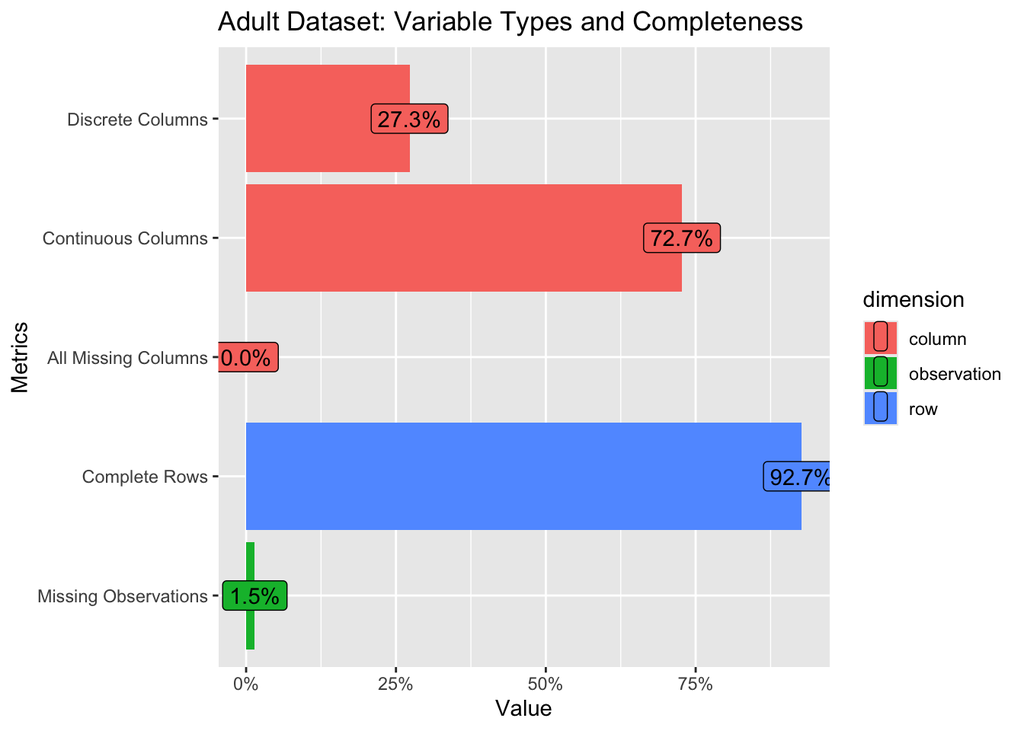

```r
# Visual structure and type overview
plot_intro(adult, title = "Adult Dataset: Variable Types and Completeness")
```

### Missing Data Summary

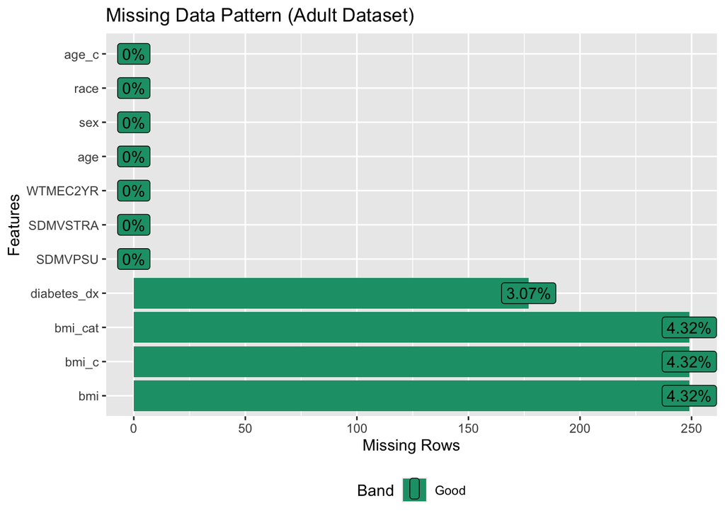

Missing data were minimal across analytic variables. BMI-related fields (bmi, bmi_c, bmi_cat) showed ~4.3% missingness, and diabetes_dx showed ~3.1%. All demographic and survey design variables were complete, indicating that missingness was limited to health-related measures and appropriate for multiple imputation.

```r
# Visualize missing data pattern
plot_missing(adult, title = "Missing Data Pattern (Adult Dataset)")
```

```r
# Summarize missingness for key analysis variables

miss_tbl <- tibble::tibble(
Variable    = c("bmi", "diabetes_dx"),
Missing_n   = c(sum(is.na(adult_eda$bmi)), sum(is.na(adult_eda$diabetes_dx))),
Missing_pct = round(c(mean(is.na(adult_eda$bmi)), mean(is.na(adult_eda$diabetes_dx))) * 100, 1)
)

knitr::kable(
miss_tbl,
caption = "Missingness for Key Analysis Variables."
)
```

Missingness for Key Analysis Variables.

| Variable | Missing_n | Missing_pct |
| --- | --- | --- |
| bmi | 249 | 4.3 |
| diabetes_dx | 177 | 3.1 |

Overall missingness was low (~7.3%). Gaps were concentrated in `bmi` (n = 249) and `diabetes_dx` (n = 177), while demographic and design variables were complete. This limited pattern of missingness is consistent with a Missing At Random (MAR) mechanism and likely reflects reduced participation in the physical examination component among certain adults.

### Exploratory Data Analysis (EDA)

#### Missing Data

Overall missingness in the analytic variables was low, with approximately **3–4%** missing data in the outcome or BMI. Multiple imputation was used to address missing predictor data. Because the diabetes outcome was not imputed, participants with missing outcome data were excluded from outcome modeling.

#### Outcome Distribution

Doctor-diagnosed diabetes prevalence in the adult cohort was approximately **11%**, which aligns with national estimates for U.S. adults during the same time period.

#### Predictor Patterns

These distributional patterns reflect established epidemiologic relationships and support the suitability of the dataset for logistic regression modeling.

#### EDA Visuals

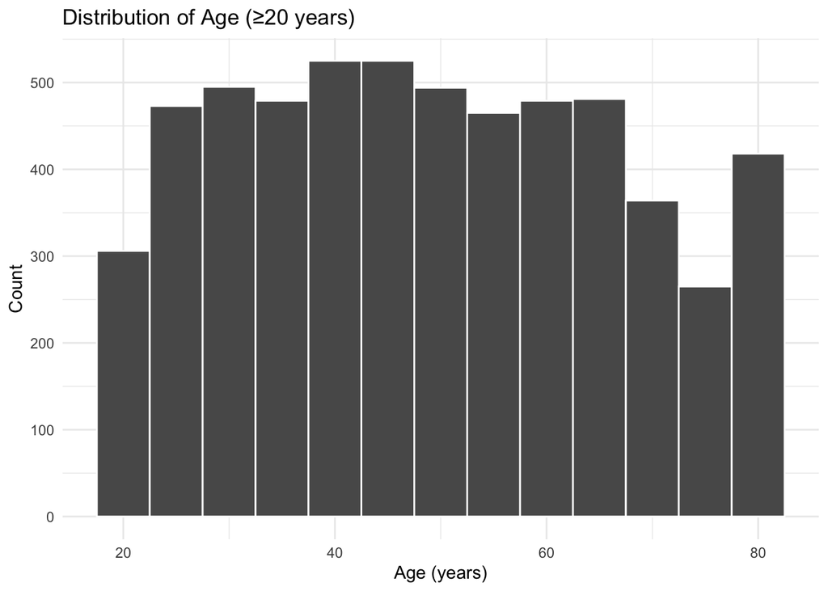

```r
# Age distribution (analytic adult)
ggplot(adult, aes(x = age)) +
  geom_histogram(binwidth = 5, color = "white") +
  labs(title = "Distribution of Age (≥20 years)", x = "Age (years)", y = "Count") +
  theme_minimal()
```

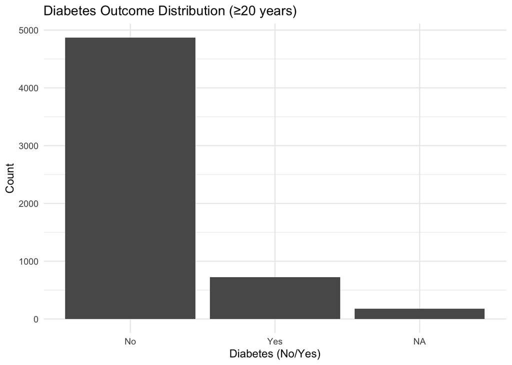

```r
# Diabetes outcome distribution
ggplot(adult, aes(x = factor(diabetes_dx, levels = c(0,1), labels = c("No","Yes")))) +
  geom_bar() +
  labs(title = "Diabetes Outcome Distribution (≥20 years)", x = "Diabetes (No/Yes)", y = "Count") +
  theme_minimal()
```

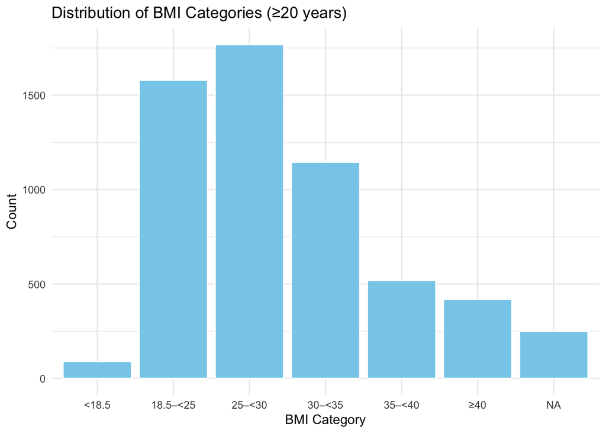

Distribution of BMI categories among adults aged ≥20 years. The majority of participants fell within the overweight (25–<30) and obese (≥30) ranges, with fewer individuals classified as underweight (<18.5). This distribution aligns with national trends in adult body composition, supporting the dataset’s representativeness for metabolic health analyses.

```r
# BMI category distribution
ggplot(adult, aes(x = bmi_cat)) +
  geom_bar(color = "white", fill = "skyblue") +
  labs(title = "Distribution of BMI Categories (≥20 years)", x = "BMI Category", y = "Count") +
  theme_minimal()
```

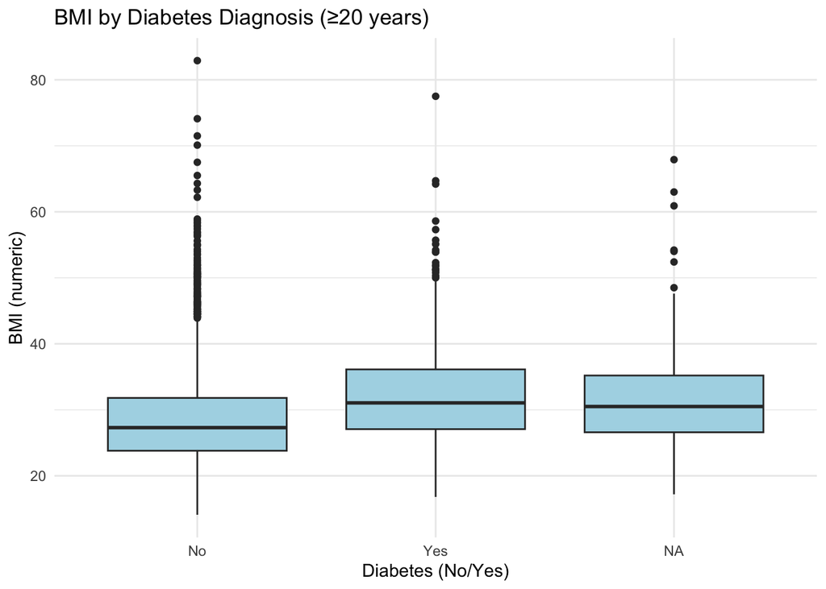

Distribution of BMI by diabetes diagnosis among adults aged ≥20 years. Participants with diabetes (`Yes`) show a higher median BMI and greater variability compared to those without diabetes (`No`), supporting the established positive association between obesity and diabetes risk.

```r
# BMI by diabetes outcome (boxplot)
# (You can’t use boxplot with categorical y, so revert to numeric BMI here)
ggplot(adult, aes(x = factor(diabetes_dx, levels = c(0,1), labels = c("No","Yes")), y = bmi)) +
  geom_boxplot(fill = "lightblue") +
  labs(title = "BMI by Diabetes Diagnosis (≥20 years)", x = "Diabetes (No/Yes)", y = "BMI (numeric)") +
  theme_minimal()
```

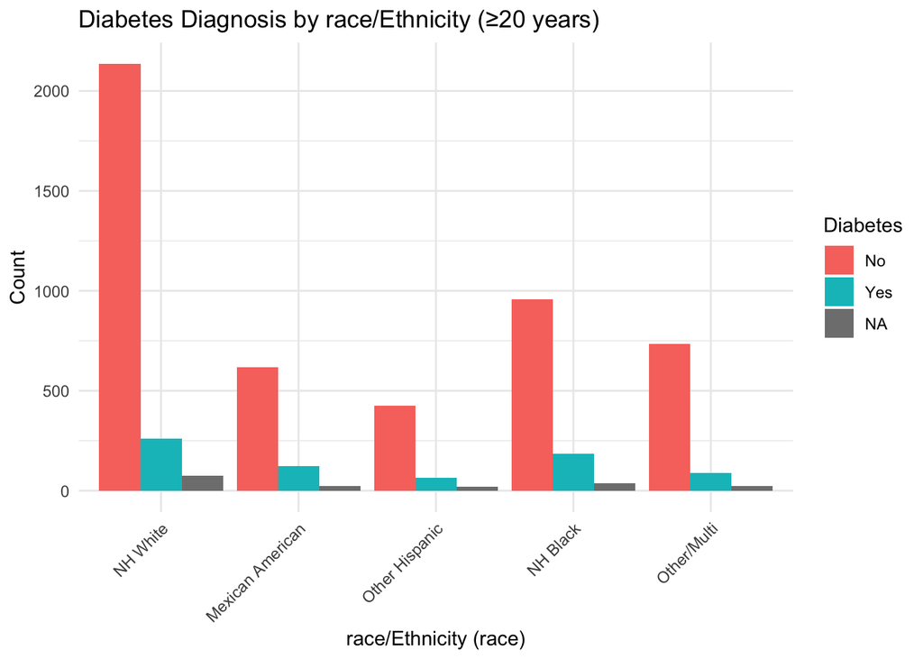

Diabetes diagnosis by race/ethnicity among adults aged ≥20 years. Non-Hispanic Black and Hispanic participants show higher proportions of diabetes diagnoses compared with Non-Hispanic White participants, reflecting known disparities in diabetes prevalence across racial and ethnic groups.

```r
# Diabetes by race (dodged bars)
ggplot(adult, aes(x = race, fill = factor(diabetes_dx, levels = c(0,1), labels = c("No","Yes")))) +
  geom_bar(position = "dodge") +
  labs(title = "Diabetes Diagnosis by race/Ethnicity (≥20 years)",
       x = "race/Ethnicity (race)", y = "Count", fill = "Diabetes") +
  theme_minimal() +
  theme(axis.text.x = element_text(angle = 45, hjust = 1))
```

## Modeling Frameworks

Two modeling frameworks were compared using identical predictors—standardized age, BMI, sex, and race—and the binary outcome `diabetes_dx`:

1. Survey-weighted logistic regression to account for the NHANES complex sampling design,
2. Bayesian logistic regression with weakly informative priors to quantify parameter uncertainty.

### Survey-Weighted Logistic Regression

The NHANES 2013–2014 data use a complex, multistage probability design involving strata (`SDMVSTRA`), primary sampling units (PSUs; `SDMVPSU`), and examination weights (`WTMEC2YR`) to ensure nationally representative estimates (National Center for Health Statistics (NCHS) 2014).

Estimates are population-weighted using NHANES survey design variables (`WTMEC2YR`, `SDMVSTRA`, `SDMVPSU`). Odds ratios are reported per one standard deviation (1 SD) increase in age and BMI, with reference groups Male and White.

```r
adult_clean <- adult %>%
  dplyr::mutate(
    sex   = forcats::fct_drop(sex),
    race = forcats::fct_drop(race),
    age_c = as.numeric(age_c),
    bmi_c = as.numeric(bmi_c)
  ) %>%
  dplyr::filter(
    !is.na(diabetes_dx),
    !is.na(age_c),
    !is.na(bmi_c),
    !is.na(sex),
    !is.na(race)
  )
```

Below is a structure of the analytic dataset used for regression modeling, showing variable names, types, and sample values (N = 5,349).

```r
str(adult_clean[, c("diabetes_dx","sex","race","age_c","bmi_c")])
```

```
'data.frame':   5349 obs. of  5 variables:
 $ diabetes_dx: num  1 1 1 0 0 0 0 0 0 1 ...
 $ sex        : Factor w/ 2 levels "Male","Female": 1 1 1 2 1 2 2 1 2 1 ...
 $ race       : Factor w/ 5 levels "NH White","Mexican American",..: 4 1 1 1 2 1 1 1 1 1 ...
 $ age_c      : num  1.132 0.278 1.303 1.36 0.392 ...
 $ bmi_c      : num  -0.3359 -0.0703 -0.0283 -1.3144 1.761 ...
```

```r
options(survey.lonely.psu = "adjust")

nhanes_design_adult <- survey::svydesign(
  id      = ~SDMVPSU,
  strata  = ~SDMVSTRA,
  weights = ~WTMEC2YR,
  nest    = TRUE,
  data    = adult_clean
)

svy_fit <- survey::svyglm(
  diabetes_dx ~ age_c + bmi_c + sex + race,
  design = nhanes_design_adult,
  family = quasibinomial()
)

summary(svy_fit)
```

```
Call:
svyglm(formula = diabetes_dx ~ age_c + bmi_c + sex + race, design = nhanes_design_adult,
    family = quasibinomial())

Survey design:
survey::svydesign(id = ~SDMVPSU, strata = ~SDMVSTRA, weights = ~WTMEC2YR,
    nest = TRUE, data = adult_clean)

Coefficients:
                     Estimate Std. Error t value Pr(>|t|)
(Intercept)          -2.65368    0.10670 -24.871 7.30e-09 ***
age_c                 1.09136    0.04255  25.649 5.73e-09 ***
bmi_c                 0.65656    0.06184  10.617 5.42e-06 ***
sexFemale            -0.25088    0.10296  -2.437  0.04077 *
raceMexican American  0.64888    0.13916   4.663  0.00162 **
raceOther Hispanic    0.48896    0.13324   3.670  0.00631 **
raceNH Black          0.47019    0.14321   3.283  0.01113 *
raceOther/Multi       0.78587    0.17986   4.369  0.00238 **
---
Signif. codes:  0 '***' 0.001 '**' 0.01 '*' 0.05 '.' 0.1 ' ' 1

(Dispersion parameter for quasibinomial family taken to be 0.8725984)

Number of Fisher Scoring iterations: 6
```

```r
svy_or <- broom::tidy(svy_fit, conf.int = TRUE) %>%
  dplyr::mutate(
    OR  = exp(estimate),
    LCL = exp(conf.low),
    UCL = exp(conf.high)
  ) %>%
  dplyr::select(term, OR, LCL, UCL, p.value) %>%
  dplyr::filter(term != "(Intercept)")
```

```r
knitr::kable(svy_or)
```

Table 1: Survey-weighted logistic regression: odds ratios (OR) and 95% confidence intervals for diabetes diagnosis among adults (NHANES 2013–2014).

| term | OR | LCL | UCL | p.value |
| --- | --- | --- | --- | --- |
| age_c | 2.9783311 | 2.6999710 | 3.2853894 | 0.0000000 |
| bmi_c | 1.9281430 | 1.6718927 | 2.2236685 | 0.0000054 |
| sexFemale | 0.7781177 | 0.6136699 | 0.9866333 | 0.0407734 |
| raceMexican American | 1.9133950 | 1.3881488 | 2.6373834 | 0.0016176 |
| raceOther Hispanic | 1.6306267 | 1.1992736 | 2.2171283 | 0.0063109 |
| raceNH Black | 1.6002930 | 1.1502138 | 2.2264885 | 0.0111339 |
| raceOther/Multi | 2.1943217 | 1.4493456 | 3.3222219 | 0.0023826 |

#### Interpretation

All predictors were statistically significant (p < 0.05), and the direction and magnitude of effects reflect well-established demographic and clinical patterns in diabetes risk.

### Bayesian Logistic Regression

Bayesian logistic regression was used to quantify parameter uncertainty and compare posterior estimates with the survey-weighted model. Weakly informative priors were applied to regularize estimates while preserving flexibility in inference.

**Model Specifications:** - **Family:** Bernoulli with logit link  
- **Data:** `adult_imp1` (N = 5,592)  
- **Chains:** 4 (2,000 iterations each; 1,000 warmup)  
- **Adaptation delta:** 0.95  
- **Weights:** Normalized NHANES examination weights (`wt_norm`, mean ≈ 1.00, SD ≈ 0.79)  
- **Predictors:** Standardized `age`, `BMI`, `sex`, and `race`

#### Define Model and Priors

```r
fml_bayes <- diabetes_dx | weights(wt_norm) ~ age_c + bmi_c + sex + race

priors <- c(
  brms::set_prior("normal(0, 2.5)", class = "b"),
  brms::set_prior("student_t(3, 0, 10)", class = "Intercept")
)
```

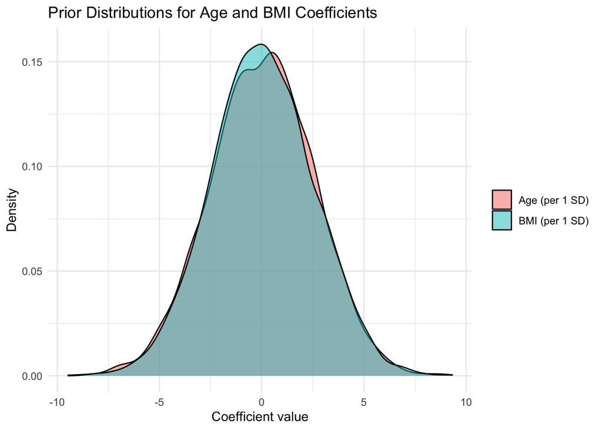

Prior distributions for standardized age and BMI coefficients, assuming Normal(0, 2.5) priors. These weakly informative priors constrain extreme coefficient values while allowing flexibility in posterior estimation, ensuring regularization without strong bias.

```r
prior_draws <- tibble::tibble(
term = rep(c("Age (per 1 SD)", "BMI (per 1 SD)"), each = 4000),
value = c(
stats::rnorm(4000, mean = 0, sd = 2.5),
stats::rnorm(4000, mean = 0, sd = 2.5)
)
)

ggplot2::ggplot(prior_draws, ggplot2::aes(x = value, fill = term)) +
ggplot2::geom_density(alpha = 0.5) +
ggplot2::theme_minimal() +
ggplot2::labs(
title = "Prior Distributions for Age and BMI Coefficients",
x = "Coefficient value",
y = "Density",
fill = NULL
)
```

#### Data Preparation Using Multiple Imputation by Chained Equations (MICE)

Multiple Imputation by Chained Equations (`MICE`) was used to address missing data in the analytic dataset (Stef van Buuren and Groothuis-Oudshoorn 2011; S. van Buuren 2012). `MICE` iteratively imputes each incomplete variable using regression models based on the available data, producing multiple completed datasets that incorporate uncertainty from the imputation process. Estimates across imputations are then combined using Rubin’s rules to obtain final parameter estimates and confidence intervals.

As an alternative to full Bayesian joint modeling, `MICE` offers a flexible and robust approach for handling missingness through chained regression equations. For large sample sizes (`n ≥ 400`), even when a single variable contains substantial missingness (up to 75%), `MICE` performs reliably under skewed, multimodal, or heavy-tailed distributions without materially affecting mean-structure estimation (S. van Buuren 2012).

In this study, Multiple Imputation by Chained Equations (`MICE`) was used to address missing predictor data. The analytic imputation dataset included `diabetes_dx`, age, BMI, sex, race/ethnicity, and the NHANES design variables `WTMEC2YR`, `SDMVPSU`, and `SDMVSTRA`. The outcome variable (`diabetes_dx`) was **not imputed**, but it was retained as a predictor for the imputation of other variables. Age was assigned normal linear regression, BMI predictive mean matching, and sex and race/ethnicity polytomous logistic regression. The NHANES examination weight, PSU, and stratum variables were not imputed but were included as auxiliary predictors. **Five imputed datasets** were generated (`m = 5`).

Because `diabetes_dx` was not imputed, participants with missing diabetes outcome data remained unavailable for outcome modeling. This resulted in **5,592 adults with an observed diabetes outcome** from the original adult cohort of 5,769. The original frequentist multiple-imputation analysis fit the logistic regression separately in all five completed datasets and pooled the estimates using Rubin’s rules. In contrast, the current Bayesian analysis uses only the **first completed imputed dataset**; therefore, uncertainty across the five imputations is not propagated through the Bayesian model.

```r
adult_imp1 <- mice::complete(imp, 1) %>%
  dplyr::mutate(
    age_c  = as.numeric(scale(age)),
    bmi_c  = as.numeric(scale(bmi)),
    wt_norm = WTMEC2YR / mean(WTMEC2YR, na.rm = TRUE),
    race = forcats::fct_relevel(race, "NH White"),
    sex  = forcats::fct_relevel(sex,  "Male")
  ) %>%
  dplyr::filter(
    !is.na(diabetes_dx),
    !is.na(age_c),
    !is.na(bmi_c),
    !is.na(sex),
    !is.na(race)
  ) %>%
  droplevels()

str(adult_imp1)
```

```
'data.frame':   5592 obs. of  11 variables:
 $ diabetes_dx: num  1 1 1 0 0 0 0 0 0 0 ...
 $ age        : num  69 54 72 73 56 61 42 56 65 26 ...
 $ bmi        : num  26.7 28.6 28.9 19.7 41.7 35.7 26.7 26.5 22 20.3 ...
 $ sex        : Factor w/ 2 levels "Male","Female": 1 1 1 2 1 2 1 2 1 2 ...
 $ race       : Factor w/ 5 levels "NH White","Mexican American",..: 4 1 1 1 2 1 3 1 1 1 ...
 $ WTMEC2YR   : num  13481 24472 57193 65542 25345 ...
 $ SDMVPSU    : num  1 1 1 2 1 1 2 1 2 2 ...
 $ SDMVSTRA   : num  112 108 109 116 111 114 106 112 112 113 ...
 $ age_c      : num  1.132 0.278 1.303 1.36 0.392 ...
 $ bmi_c      : num  -0.3354 -0.0686 -0.0264 -1.3185 1.7713 ...
 $ wt_norm    : num  0.339 0.616 1.44 1.65 0.638 ...
```

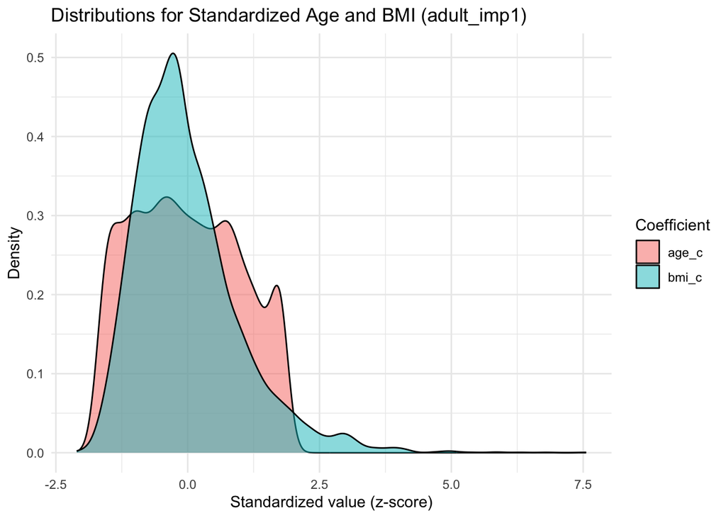

```r
adult_long <- adult_imp1 %>%
dplyr::select(bmi_c, age_c) %>%
tidyr::pivot_longer(
cols = dplyr::everything(),
names_to = "Coefficient",
values_to = "Value"
)

ggplot2::ggplot(adult_long, ggplot2::aes(x = Value, fill = Coefficient)) +
ggplot2::geom_density(alpha = 0.5) +
ggplot2::theme_minimal() +
ggplot2::labs(
title = "Distributions for Standardized Age and BMI (adult_imp1)",
x = "Standardized value (z-score)",
y = "Density",
fill = "Coefficient"
)
```

The Bayesian model was fit using the first completed imputed dataset and included 5,592 adults with an observed diabetes outcome. The survey-weighted frequentist analysis used a separate complete-case dataset of 5,349 adults. Therefore, the two models were not fit to the same analytic sample.

#### Fit the Model

```r
priors <- c(
  brms::set_prior("normal(0, 2.5)", class = "b"),
  brms::set_prior("student_t(3, 0, 10)", class = "Intercept")
)

bayes_fit <- brms::brm(
  formula = diabetes_dx | weights(wt_norm) ~ age_c + bmi_c + sex + race,
  data    = adult_imp1,
  family  = bernoulli(link = "logit"),
  prior   = priors,
  chains  = 4, iter = 2000, seed = 123,
  control = list(adapt_delta = 0.95),
  refresh = 0
)
```

```
Running MCMC with 4 sequential chains...

Chain 1 finished in 11.4 seconds.
Chain 2 finished in 11.5 seconds.
Chain 3 finished in 10.1 seconds.
Chain 4 finished in 10.9 seconds.

All 4 chains finished successfully.
Mean chain execution time: 11.0 seconds.
Total execution time: 44.3 seconds.
```

```r
summary(bayes_fit)
```

```
 Family: bernoulli
  Links: mu = logit
Formula: diabetes_dx | weights(wt_norm) ~ age_c + bmi_c + sex + race
   Data: adult_imp1 (Number of observations: 5592)
  Draws: 4 chains, each with iter = 2000; warmup = 1000; thin = 1;
         total post-warmup draws = 4000

Regression Coefficients:
                    Estimate Est.Error l-95% CI u-95% CI Rhat Bulk_ESS Tail_ESS
Intercept              -2.65      0.09    -2.82    -2.49 1.00     3518     3241
age_c                   1.07      0.06     0.96     1.19 1.00     3140     2864
bmi_c                   0.65      0.04     0.56     0.73 1.00     3299     2844
sexFemale              -0.25      0.09    -0.43    -0.06 1.00     3828     2924
raceMexicanAmerican     0.66      0.17     0.33     0.99 1.00     4257     3227
raceOtherHispanic       0.45      0.22     0.00     0.87 1.00     4004     2838
raceNHBlack             0.49      0.14     0.21     0.77 1.00     4583     2939
raceOtherDMulti         0.75      0.18     0.39     1.09 1.00     3879     2898

Draws were sampled using sample(hmc). For each parameter, Bulk_ESS
and Tail_ESS are effective sample size measures, and Rhat is the potential
scale reduction factor on split chains (at convergence, Rhat = 1).
```

Bayesian logistic regression model fit summary for diabetes diagnosis (`diabetes_dx`) with standardized predictors (age, BMI, sex, and race) and normalized NHANES weights. All four MCMC chains (4,000 post-warmup draws) converged successfully (`R̂ ≈ 1.00`), indicating stable estimation across parameters.

```r
# Extract fixed effects and convert to odds ratios
bayes_fixef <- brms::fixef(bayes_fit, summary = TRUE)

bayes_or <- bayes_fixef %>%
  as.data.frame() %>%
  tibble::rownames_to_column("term") %>%
  dplyr::mutate(
    OR  = exp(Estimate),
    LCL = exp(Q2.5),
    UCL = exp(Q97.5)
  )
```

#### Posterior Odd Ratios (Main Results)

```r
knitr::kable(
dplyr::mutate(bayes_or, dplyr::across(c(OR, LCL, UCL), ~ round(.x, 2)))
)
```

Table 2

| term | Estimate | Est.Error | Q2.5 | Q97.5 | OR | LCL | UCL |
| --- | --- | --- | --- | --- | --- | --- | --- |
| Intercept | -2.6476433 | 0.0850175 | -2.8223668 | -2.4860107 | 0.07 | 0.06 | 0.08 |
| age_c | 1.0738578 | 0.0563973 | 0.9649983 | 1.1871605 | 2.93 | 2.62 | 3.28 |
| bmi_c | 0.6463041 | 0.0448721 | 0.5606534 | 0.7332800 | 1.91 | 1.75 | 2.08 |
| sexFemale | -0.2484288 | 0.0944717 | -0.4301698 | -0.0626043 | 0.78 | 0.65 | 0.94 |
| raceMexicanAmerican | 0.6568366 | 0.1698561 | 0.3304196 | 0.9853574 | 1.93 | 1.39 | 2.68 |
| raceOtherHispanic | 0.4500722 | 0.2220717 | 0.0040297 | 0.8747466 | 1.57 | 1.00 | 2.40 |
| raceNHBlack | 0.4938342 | 0.1418123 | 0.2138916 | 0.7654736 | 1.64 | 1.24 | 2.15 |
| raceOtherDMulti | 0.7494149 | 0.1772106 | 0.3901788 | 1.0898289 | 2.12 | 1.48 | 2.97 |

```r
# Combine survey-weighted and Bayesian OR results
svy_tbl <- svy_or %>%
  mutate(Model = "Survey-weighted")

bayes_tbl <- bayes_or %>%
  mutate(Model = "Bayesian") %>%
  filter(term != "Intercept")

# Long format
all_tbl <- bind_rows(svy_tbl, bayes_tbl) %>%
  mutate(
    term = case_when(
      grepl("bmi", term, ignore.case = TRUE) ~ "BMI (per 1 SD)",
      grepl("age", term, ignore.case = TRUE) ~ "Age (per 1 SD)",
      grepl("^sexFemale$", term) ~ "Female (vs. Male)",
# ---- Race recoding (handles ALL messy variants) ----
      grepl("Mexican", term, ignore.case = TRUE) ~ "Mexican American (vs. White)",
      grepl("Black", term, ignore.case = TRUE) ~ "Black (vs. White)",
      grepl("Hispanic", term, ignore.case = TRUE) ~ "Hispanic (vs. White)",
      grepl("Other", term, ignore.case = TRUE) ~ "Other/Multi (vs. White)",
      TRUE ~ term
    ),
    OR_CI = sprintf("%.2f (%.2f – %.2f)", OR, LCL, UCL)
  ) %>%
  select(Model, term, OR_CI)

# Wide format
vertical_tbl <- all_tbl %>%
  pivot_wider(
    names_from = Model,
    values_from = OR_CI
  ) %>%
  arrange(term)

# Output
knitr::kable(vertical_tbl,
             align = "lcc",
             caption = "Odds Ratios (95% CI) Across Survey-weighted and Bayesian Models")
```

Table 3: Odds Ratios (95% CI) for Key Predictors Across Survey-weighted and Bayesian Models.

Odds Ratios (95% CI) Across Survey-weighted and Bayesian Models

| term | Survey-weighted | Bayesian |
| --- | --- | --- |
| Age (per 1 SD) | 2.98 (2.70 – 3.29) | 2.93 (2.62 – 3.28) |
| BMI (per 1 SD) | 1.93 (1.67 – 2.22) | 1.91 (1.75 – 2.08) |
| Black (vs. White) | 1.60 (1.15 – 2.23) | 1.64 (1.24 – 2.15) |
| Female (vs. Male) | 0.78 (0.61 – 0.99) | 0.78 (0.65 – 0.94) |
| Hispanic (vs. White) | 1.63 (1.20 – 2.22) | 1.57 (1.00 – 2.40) |
| Mexican American (vs. White) | 1.91 (1.39 – 2.64) | 1.93 (1.39 – 2.68) |
| Other/Multi (vs. White) | 2.19 (1.45 – 3.32) | 2.12 (1.48 – 2.97) |

### Coefficient Comparison Plot

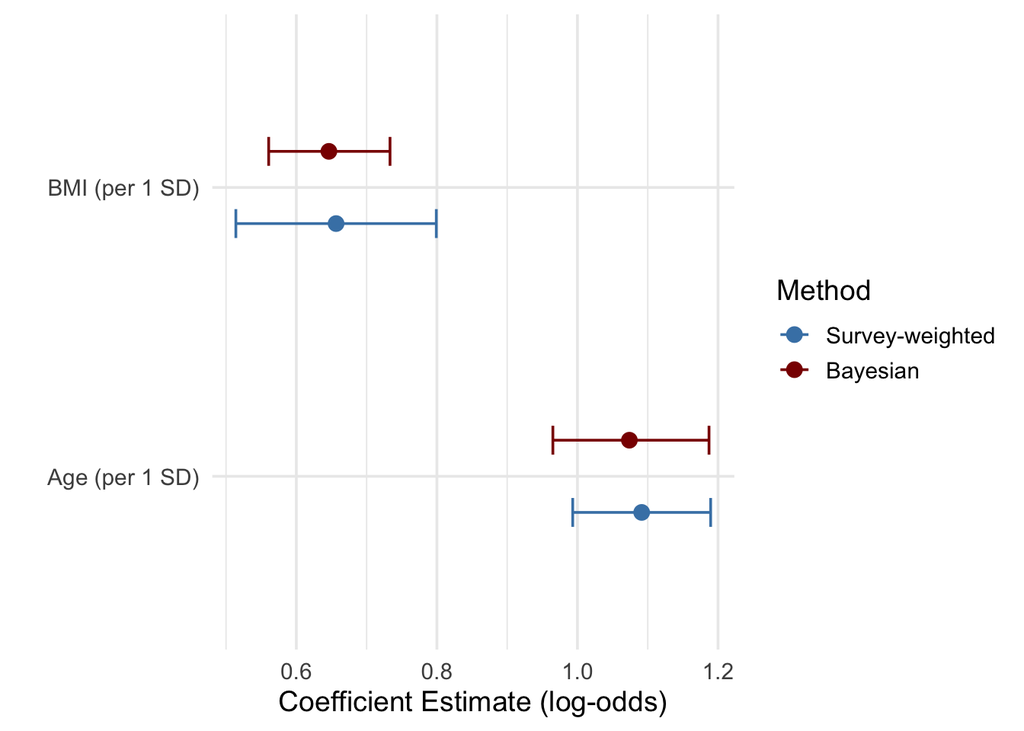

Coefficient estimates (log-odds) from survey-weighted and Bayesian logistic regression models for Age and BMI.

```r
library(dplyr)
library(broom)
library(broom.mixed)
library(ggplot2)

# Survey-weighted coefficients
svy_df <- tidy(svy_fit, conf.int = TRUE) %>%
  filter(term %in% c("age_c", "bmi_c")) %>%
  mutate(
    Method = "Survey-weighted",
    term = recode(term, "age_c" = "Age (per 1 SD)", "bmi_c" = "BMI (per 1 SD)")
  )

# Bayesian coefficients
bayes_df <- tidy(bayes_fit, conf.int = TRUE) %>%
  filter(term %in% c("age_c", "bmi_c")) %>%
  mutate(
    Method = "Bayesian",
    term = recode(term, "age_c" = "Age (per 1 SD)", "bmi_c" = "BMI (per 1 SD)")
  )

# Combine
coef_df <- bind_rows(svy_df, bayes_df) %>%
  mutate(Method = factor(Method, levels = c("Survey-weighted", "Bayesian")))

# Plot
ggplot(coef_df, aes(x = term, y = estimate, color = Method)) +
  geom_point(position = position_dodge(width = 0.5), size = 3) +
  geom_errorbar(aes(ymin = conf.low, ymax = conf.high),
                width = 0.2,
                position = position_dodge(width = 0.5)) +
  coord_flip() +
  labs(
    x = "",
    y = "Coefficient Estimate (log-odds)"
  ) +
  theme_minimal(base_size = 14) +
  scale_color_manual(values = c("Survey-weighted" = "steelblue",
                                "Bayesian" = "darkred"))
```

The coefficient comparison plot shows that both modeling approaches identify Age and BMI as strong positive predictors of diabetes. The survey-weighted and Bayesian estimates are closely aligned, with overlapping intervals, indicating consistent effect sizes across methods. This agreement supports the robustness of the findings regardless of whether weighting or Bayesian regularization is used.

#### Posterior Coefficients (log-odds scale)

##### Interpretation

- **Age and BMI** show strong positive associations with diabetes risk in the posterior distribution.
- **Female sex** shows a clear protective association.
- **Racial/ethnic groups**, particularly Mexican American, NH Black, and Other/Multi, have elevated odds relative to NH Whites.
- Posterior estimates demonstrate consistent directionality with survey-weighted models, with Bayesian credible intervals providing more intuitive uncertainty quantification.

#### Diagnostics and Model Fit

```r
knitr::kable(as.data.frame(brms::bayes_R2(bayes_fit)))
```

Table 4: Bayesian R² Summary

|  | Estimate | Est.Error | Q2.5 | Q97.5 |
| --- | --- | --- | --- | --- |
| R2 | 0.13792 | 0.0119499 | 0.114566 | 0.1616394 |

```r
diag <- posterior::summarise_draws(bayes_fit, "rhat", "ess_bulk", "ess_tail")

diag_b <- diag |>
dplyr::as_tibble() |>
dplyr::filter(grepl("^b_", .data$variable)) |>
dplyr::transmute(
Parameter = .data$variable,
Rhat      = .data$rhat,
Bulk_ESS  = .data$ess_bulk,
Tail_ESS  = .data$ess_tail
)

knitr::kable(diag_b, digits = 1)
```

Table 5: MCMC Diagnostics (R-hat and Effective Sample Sizes) for Model Parameters

| Parameter | Rhat | Bulk_ESS | Tail_ESS |
| --- | --- | --- | --- |
| b_Intercept | 1 | 3518.4 | 3241.1 |
| b_age_c | 1 | 3139.6 | 2863.8 |
| b_bmi_c | 1 | 3298.7 | 2843.7 |
| b_sexFemale | 1 | 3828.4 | 2924.2 |
| b_raceMexicanAmerican | 1 | 4256.8 | 3226.8 |
| b_raceOtherHispanic | 1 | 4004.3 | 2837.9 |
| b_raceNHBlack | 1 | 4582.5 | 2939.4 |
| b_raceOtherDMulti | 1 | 3878.8 | 2897.7 |

All parameters achieved R̂ ≈ 1.00 and effective sample sizes >2,000, indicating excellent convergence. The Bayesian R² ≈ 0.13, showing that age, BMI, sex, and race explain about 13% of diabetes variability.

#### Model Comparison

```r
invisible(capture.output({
fit_no_race <- update(bayes_fit, formula = update(fml_bayes, . ~ . - race))
fit_no_sex  <- update(bayes_fit, formula = update(fml_bayes, . ~ . - sex))
}))

loo_base    <- loo::loo(bayes_fit)
loo_no_race <- loo::loo(fit_no_race)
loo_no_sex  <- loo::loo(fit_no_sex)

cmp_df <- as.data.frame(loo::loo_compare(loo_base, loo_no_race, loo_no_sex))
cmp_df$Model <- rownames(cmp_df)
cmp_df <- cmp_df[, c("Model", setdiff(names(cmp_df), "Model"))]

knitr::kable(
cmp_df,
caption = "LOO Comparison (higher elpd_loo indicates better predictive performance)."
)
```

Bayesian Model Comparison (LOO): Base Model vs. Reduced Models Without Race or Sex

|  | Model | elpd_diff | se_diff | elpd_loo | se_elpd_loo | p_loo | se_p_loo | looic | se_looic |
| --- | --- | --- | --- | --- | --- | --- | --- | --- | --- |
| bayes_fit | bayes_fit | 0.000000 | 0.000000 | -1576.335 | 56.95690 | 8.748750 | 0.5389078 | 3152.670 | 113.9138 |
| fit_no_sex | fit_no_sex | -2.132116 | 3.286874 | -1578.467 | 57.11817 | 7.095472 | 0.4486393 | 3156.935 | 114.2363 |
| fit_no_race | fit_no_race | -14.061635 | 6.338019 | -1590.397 | 54.48886 | 5.349549 | 0.3571378 | 3180.794 | 108.9777 |

#### Posterior Predictive Checks

```r
yobs <- adult_imp1$diabetes_dx
```

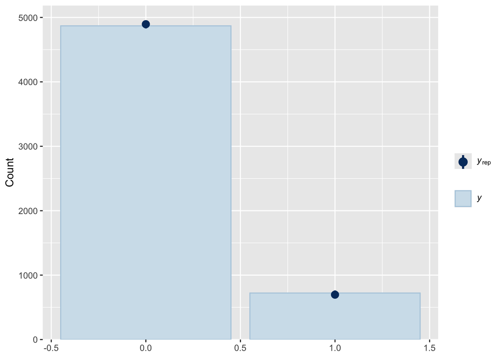

Figure 1: Posterior Predictive Check: Observed vs. Replicated Outcome Distribution (Bars)

```r
bayesplot::pp_check(bayes_fit, type = "bars", nsamples = 100)
```

The close alignment between observed (`y`) and replicated (`y_rep`) outcome distributions indicates that the Bayesian model reproduces the empirical data structure well.

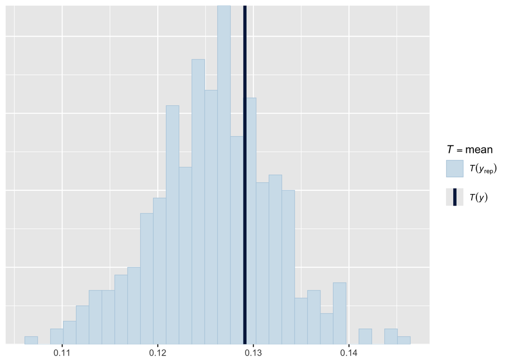

Figure 2: Posterior predictive check for the mean of the binary outcome, comparing the observed mean (`T(y)`) to replicated means (`T(y_rep)`) across posterior draws.

```r
yrep <- brms::posterior_predict(bayes_fit, ndraws = 400)
bayesplot::ppc_stat(y = yobs, yrep = yrep, stat = "mean")
```

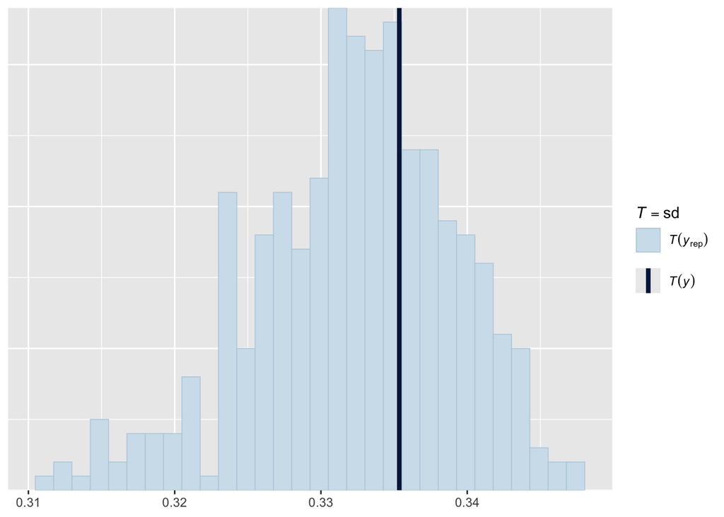

Figure 3: Posterior predictive check for the standard deviation of the binary outcome (`T(y)`) compared with replicated datasets (`T(y_rep)`).

```r
yrep <- brms::posterior_predict(bayes_fit, ndraws = 400)
bayesplot::ppc_stat(y = yobs, yrep = yrep, stat = "sd")
```

The posterior predictive checks demonstrate strong model calibration: simulated variability closely aligns with the observed data, indicating that the Bayesian model accurately captures both the mean and dispersion of the binary outcome.

#### MCMC Diagnostics and Posterior Distributions

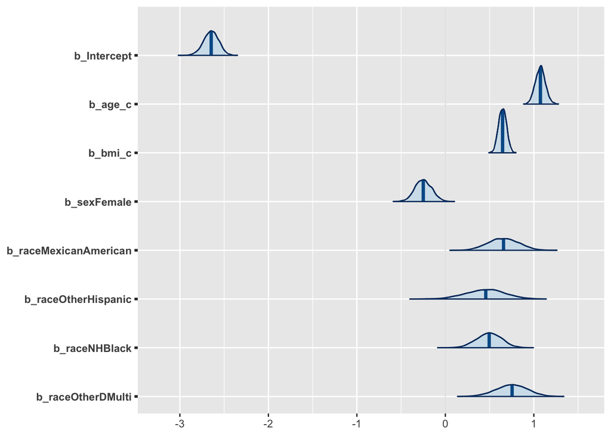

Figure 4: Posterior distributions (95% credible mass) for slope parameters in the Bayesian logistic regression model.

```r
bayesplot::mcmc_areas(as.array(bayes_fit), regex_pars = "^b_", prob = 0.95)
```

All posteriors appear unimodal and well‐centered, indicating stable estimation and strong convergence across parameters. Positive coefficients (e.g., age, BMI) correspond to increased diabetes risk, while negative coefficients (e.g., female sex) indicate protective associations.

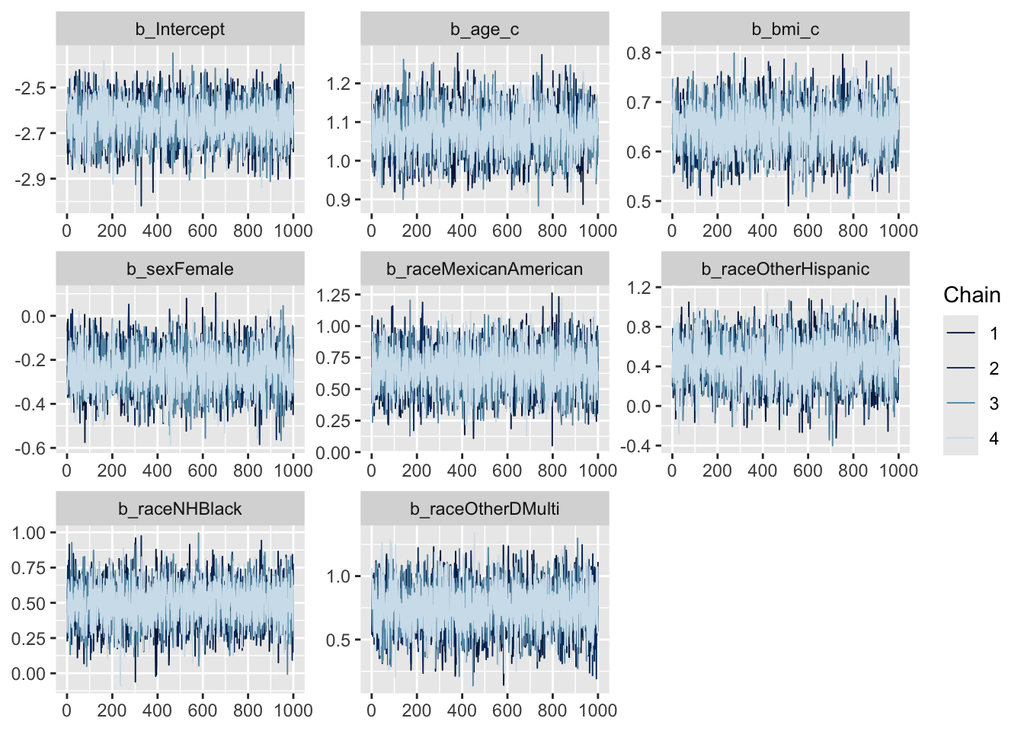

Figure 5: Trace plots for slope parameters across four MCMC chains, demonstrating effective chain mixing and stationarity.

```r
bayesplot::mcmc_trace(as.array(bayes_fit), regex_pars = "^b_")
```

All parameters exhibit well-mixed, stable trace patterns with no visible drift, supporting convergence diagnostics (`R̂` ≈ 1.00). This confirms that the posterior samples are representative and that the Bayesian model converged reliably.

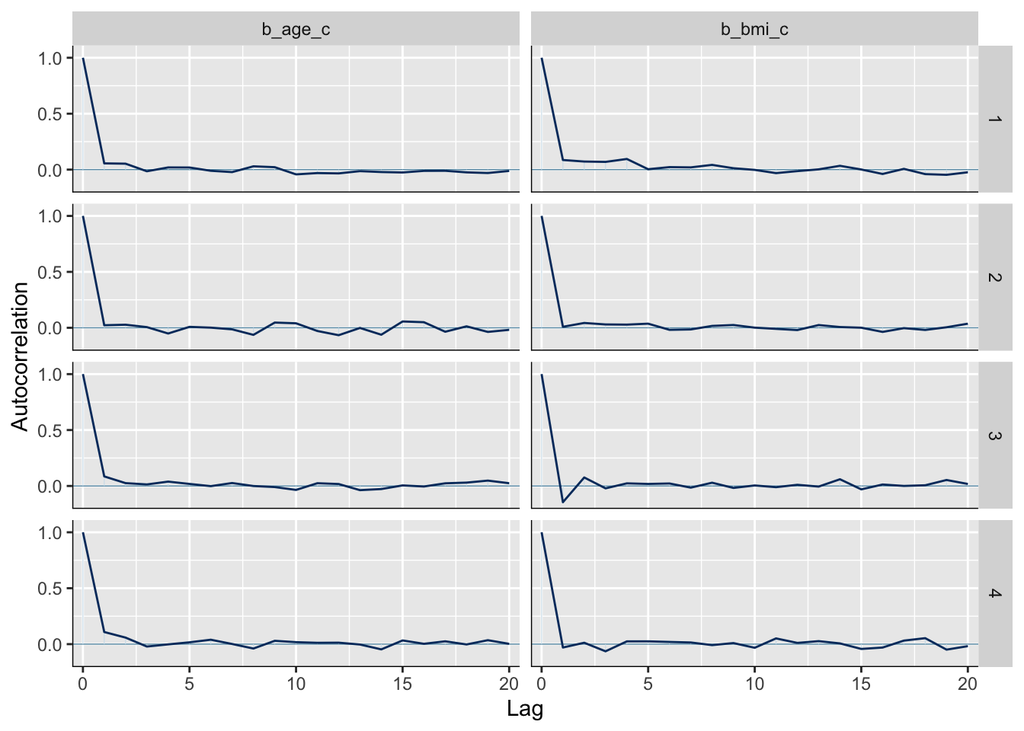

Figure 6: Autocorrelation plots for posterior samples of age and BMI coefficients, showing rapid decay of autocorrelation with lag. Low autocorrelation across lags confirms efficient MCMC sampling and good chain independence.

```r
post_array <- posterior::as_draws_array(bayes_fit)
bayesplot::mcmc_acf(post_array, pars = c("b_age_c", "b_bmi_c"))
```

- Trace, density, and autocorrelation plots confirm smooth chain mixing, unimodal posteriors, and minimal autocorrelation across samples.
- All four chains showed strong convergence with no signs of divergence or non-stationarity.
- Trace plots revealed stable, overlapping chains with consistent mixing across iterations, while autocorrelation decayed rapidly toward zero, confirming efficient sampling and low dependency between successive draws.
- Together with R̂ ≈ 1.00 and large effective sample sizes, these diagnostics indicate a well-behaved posterior and reliable inference.

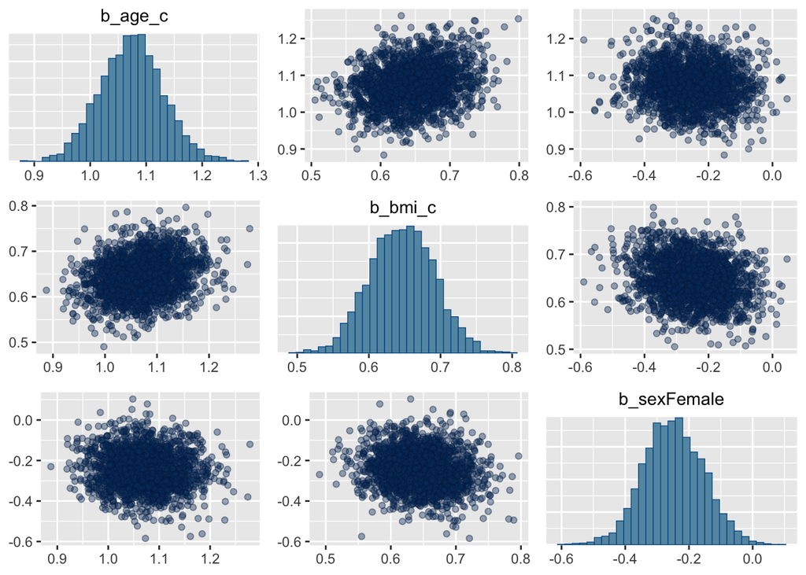

Figure 7: Posterior correlation among key regression parameters. Off-diagonal panels show pairwise joint posterior distributions, while diagonals show marginal posteriors. Weak correlations indicate predictors contribute independent information, supporting model stability.

```r
bayesplot::mcmc_pairs(
posterior::as_draws_array(bayes_fit),
pars = c("b_age_c", "b_bmi_c", "b_sexFemale"),
off_diag_args = list(size = 1.5, alpha = 0.4)
)
```

The posterior pairwise correlation plot (above) shows that the regression coefficients (`age_c`, `bmi_c`, and `sexFemale`) have minimal posterior correlation, indicated by round, diffuse scatterplots without strong directional patterns. This suggests that these predictors contribute distinct, non-redundant information to the diabetes model. The diagonal panels show smooth, unimodal posterior densities, confirming stable estimates. The weak correlations further indicate low multicollinearity and well-behaved MCMC sampling, supporting reliable inference.

#### Prior vs. Posterior

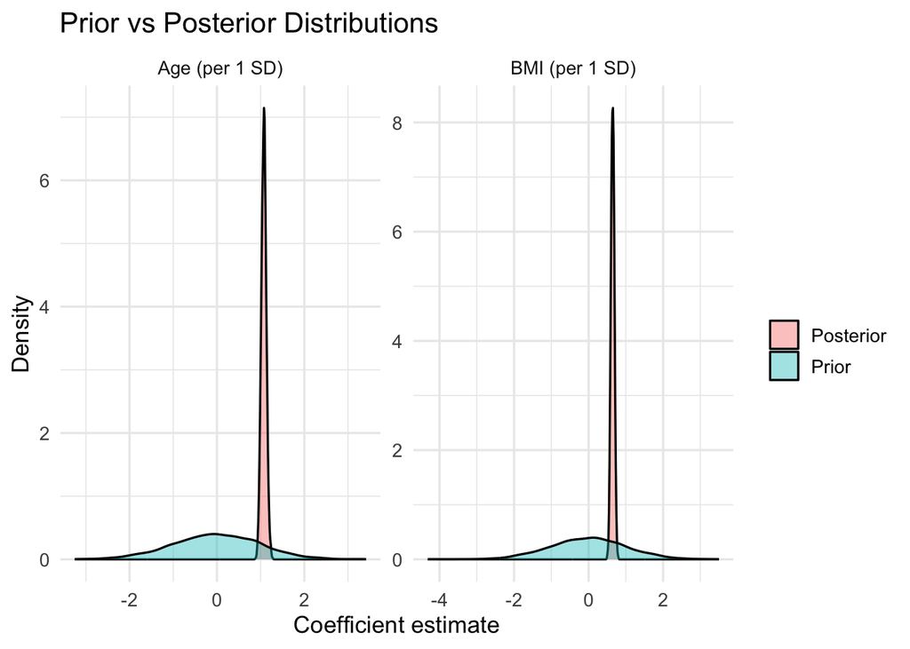

Figure 8: Prior vs Posterior Distributions

```r
# Extract posterior draws as a matrix, then convert to tibble
post <- as_draws_matrix(bayes_fit) %>%   # safer than as_draws_df for manipulation
  as.data.frame() %>%
  select(b_bmi_c, b_age_c) %>%
  pivot_longer(
    everything(),
    names_to = "term",
    values_to = "estimate"
  ) %>%
  mutate(
    term = case_when(
      term == "b_bmi_c" ~ "BMI (per 1 SD)",
      term == "b_age_c" ~ "Age (per 1 SD)"
    ),
    type = "Posterior"
  )
prior_draws <- tibble(
  term = rep(c("BMI (per 1 SD)", "Age (per 1 SD)"), each = 4000),
  estimate = c(rnorm(4000, 0, 1), rnorm(4000, 0, 1)),
  type = "Prior"
)
combined_draws <- bind_rows(prior_draws, post)

ggplot(combined_draws, aes(x = estimate, fill = type)) +
  geom_density(alpha = 0.4) +
  facet_wrap(~ term, scales = "free", ncol = 2) +
  theme_minimal(base_size = 13) +
  labs(
    title = "Prior vs Posterior Distributions",
    x = "Coefficient estimate",
    y = "Density",
    fill = ""
  )
```

#### Model Fit and Calibration

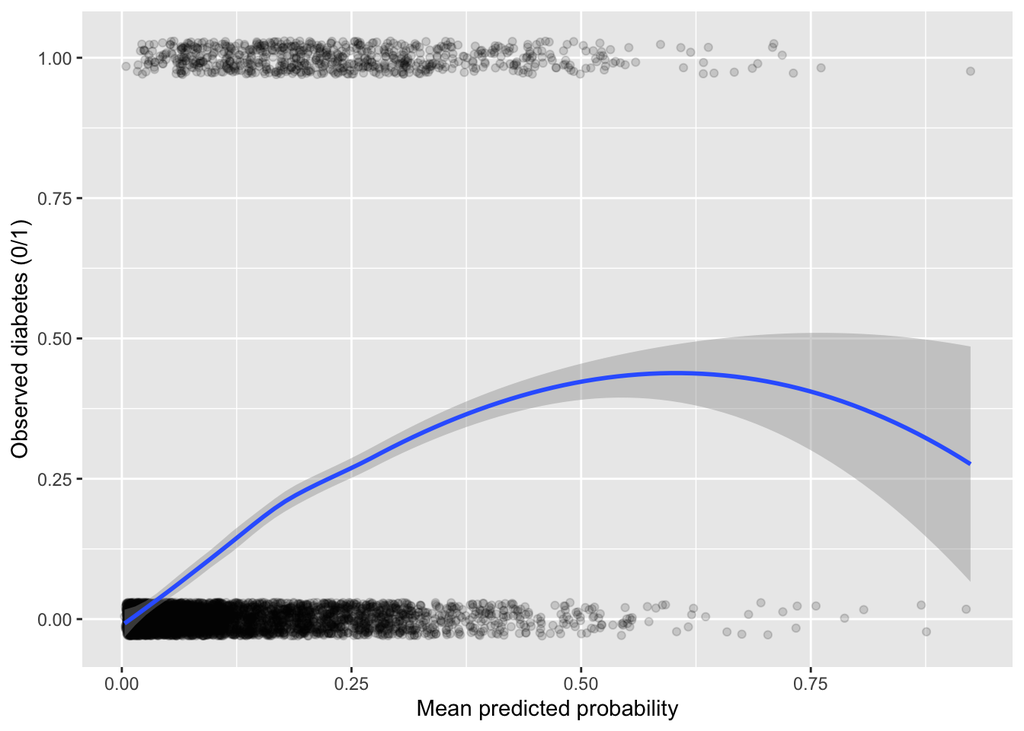

```r
pred_mean <- colMeans(brms::posterior_epred(bayes_fit))
ggplot(data.frame(pred = pred_mean, obs = yobs),
aes(x = pred, y = obs)) +
geom_point(alpha = 0.15, position = position_jitter(height = 0.03)) +
geom_smooth(method = "loess", se = TRUE) +
labs(x = "Mean predicted probability", y = "Observed diabetes (0/1)")
```

```r
# 1. Survey-weighted prevalence

svy_mean <- svymean(~diabetes_dx, nhanes_design_adult, na.rm = TRUE)

# 2. Posterior predictive prevalence (per draw)

pp_samples <- brms::posterior_predict(bayes_fit, ndraws = 1000)
pp_proportion <- rowMeans(pp_samples)

# 3. Build comparison table (imputed row removed)

summary_table <- tibble(
Method = c(
"Survey-weighted mean (NHANES)",
"Posterior predictive mean"
),
diabetes_mean = c(
coef(svy_mean),
mean(pp_proportion)
),
SE = c(
SE(svy_mean),
NA
)
)

kable(
summary_table,
digits = 4,
caption = "Comparison of Diabetes Prevalence Across Methods"
)
```

Comparison of Diabetes Prevalence Across Methods

| Method | diabetes_mean | SE |
| --- | --- | --- |
| Survey-weighted mean (NHANES) | 0.1032 | 0.0054 |
| Posterior predictive mean | 0.1260 | NA |

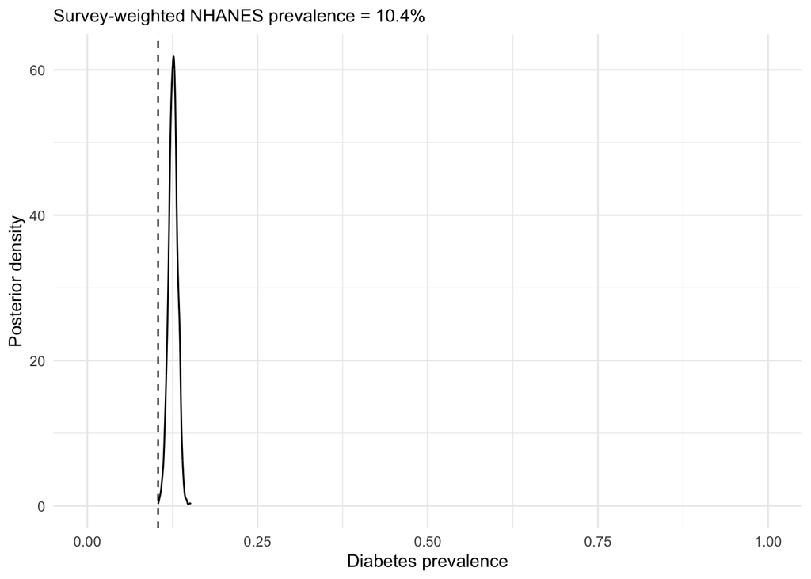

```r
# Posterior predictive prevalence (replicated datasets)

yrep <- brms::posterior_predict(bayes_fit, ndraws = 2000)   # draws x observations (0/1)
post_prev <- rowMeans(yrep)                                 # prevalence each posterior draw

# Survey-weighted observed prevalence (population estimate)

des_obs <- survey::svydesign(
id = ~SDMVPSU, strata = ~SDMVSTRA, weights = ~WTMEC2YR,
nest = TRUE, data = adult_imp1
)
obs <- survey::svymean(~diabetes_dx, des_obs, na.rm = TRUE)
obs_prev  <- as.numeric(obs["diabetes_dx"])
obs_se    <- as.numeric(SE(obs)["diabetes_dx"])
obs_lcl   <- max(0, obs_prev - 1.96 * obs_se)
obs_ucl   <- min(1, obs_prev + 1.96 * obs_se)

# Plot: posterior density with weighted point estimate and 95% CI band

ggplot(data.frame(prev = post_prev), aes(x = prev)) +
geom_density(alpha = 0.6) +
annotate("rect", xmin = obs_lcl, xmax = obs_ucl, ymin = 0, ymax = Inf, alpha = 0.15) +
geom_vline(xintercept = obs_prev, linetype = 2) +
coord_cartesian(xlim = c(0, 1)) +
labs(
  x = "Diabetes prevalence",
  y = "Posterior density",
  subtitle = sprintf("Survey-weighted NHANES prevalence = %.1f%%", obs_prev * 100)
) +
theme_minimal()
```

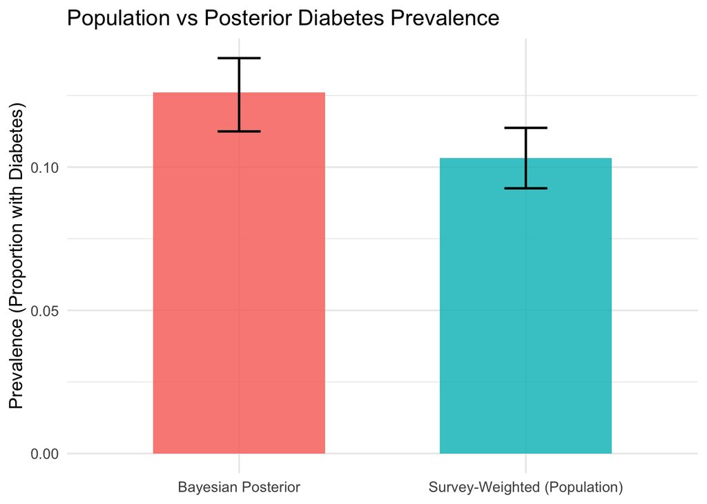

Population vs Posterior Diabetes Prevalence

```r
# --- 1. Survey-weighted (Population) prevalence ---
pop_est <- svymean(~diabetes_dx, nhanes_design_adult, na.rm = TRUE)
pop_prev <- as.numeric(pop_est)
pop_se <- as.numeric(SE(pop_est))
pop_ci <- c(pop_prev - 1.96 * pop_se, pop_prev + 1.96 * pop_se)

# --- 2. Bayesian posterior prevalence ---
# Uses your existing pp_samples matrix
pp_proportion <- rowMeans(pp_samples)                   # prevalence per posterior draw
post_prev <- mean(pp_proportion)                        # posterior mean prevalence
post_ci <- quantile(pp_proportion, c(0.025, 0.975))     # 95% credible interval

# --- 3. Combine into one data frame ---
bar_df <- tibble(
  Source     = c("Survey-Weighted (Population)", "Bayesian Posterior"),
  Prevalence = c(pop_prev, post_prev),
  CI_low     = c(pop_ci[1], post_ci[1]),
  CI_high    = c(pop_ci[2], post_ci[2])
)

# --- 4. Plot ---
ggplot(bar_df, aes(x = Source, y = Prevalence, fill = Source)) +
  geom_col(alpha = 0.85, width = 0.6) +
  geom_errorbar(
    aes(ymin = CI_low, ymax = CI_high),
    width = 0.15,
    color = "black",
    linewidth = 0.8
  ) +
  guides(fill = "none") +
  labs(
    title = "Population vs Posterior Diabetes Prevalence",
    y = "Prevalence (Proportion with Diabetes)",
    x = NULL
  ) +
  theme_minimal(base_size = 13)
```

#### Internal Validation: Individual-Level Predictions

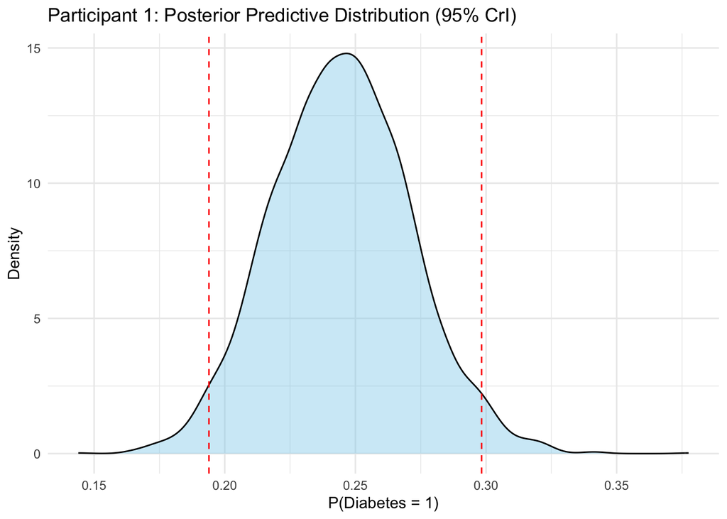

Posterior predictive distribution for an example participant, showing the estimated probability of diabetes (P = 1) with 95% credible intervals (red dashed lines).

```r
adult_means <- adult_imp1 %>% summarise(
age_mean = mean(age, na.rm = TRUE),
age_sd   = sd(age, na.rm = TRUE),
bmi_mean = mean(bmi, na.rm = TRUE),
bmi_sd   = sd(bmi, na.rm = TRUE)
)

to_model_row <- function(age_raw, bmi_raw, sex_lab, race_lab) {
tibble(
age_c  = (age_raw - adult_means$age_mean)/adult_means$age_sd,
bmi_c  = (bmi_raw - adult_means$bmi_mean)/adult_means$bmi_sd,
sex    = factor(sex_lab,   levels = levels(adult_imp1$sex)),
race  = factor(race_lab, levels = levels(adult_imp1$race)),
wt_norm = 1
)
}

plot_post_density <- function(df_row, title_txt) {
phat <- posterior_linpred(bayes_fit, newdata = df_row, transform = TRUE)
ci95 <- quantile(phat, c(0.025, 0.975))
ggplot(data.frame(pred = as.numeric(phat)), aes(x = pred)) +
geom_density(fill = "skyblue", alpha = 0.4) +
geom_vline(xintercept = ci95[1], linetype = "dashed", color = "red") +
geom_vline(xintercept = ci95[2], linetype = "dashed", color = "red") +
labs(x = "P(Diabetes = 1)", y = "Density", title = title_txt) +
theme_minimal()
}

p1 <- to_model_row(adult$age[1], adult$bmi[1],
as.character(adult$sex[1]), as.character(adult$race[1]))
plot_post_density(p1, "Participant 1: Posterior Predictive Distribution (95% CrI)")
```

Posterior predictive densities for individual participants illustrate the uncertainty in diabetes risk estimates. The credible intervals quantify plausible risk ranges, emphasizing how posterior variability captures uncertainty rather than single-point predictions.

#### Posterior Predictions and Inverse Inference

[figure not shown]

Inverse prediction of BMI needed to reach a target diabetes probability (illustrative example).

```r
library(dplyr)
library(ggplot2)

# 1. Grid of BMI values (RAW BMI from 18 to 40)
bmi_seq <- seq(18, 40, by = 0.5)

# 2. Newdata using the SAME factor levels as adult_imp1
newdata_grid <- data.frame(
  age_c  = 40,   # NOTE: Namita used 40 here even though age_c is standardized
  bmi_c  = bmi_seq,   # she also used raw BMI in a column named bmi_c
  sex    = factor("Female",          levels = levels(adult_imp1$sex)),
  race   = factor("Mexican American", levels = levels(adult_imp1$race)),
  wt_norm = 1
)

# 3. Posterior predicted probabilities
pred_probs <- brms::posterior_linpred(
  bayes_fit,
  newdata   = newdata_grid,
  transform = TRUE
)

# 4. Mean predicted probability at each BMI
prob_mean <- colMeans(pred_probs)

pred_df <- dplyr::bind_cols(newdata_grid, prob_mean = prob_mean)

# 5. Target probability
target_prob <- 0.30

# Find the BMI whose predicted prob is closest to the target
closest <- pred_df[which.min(abs(pred_df$prob_mean - target_prob)), , drop = FALSE]

# 6. Plot
ggplot(pred_df, aes(x = bmi_c, y = prob_mean)) +
  geom_line(color = "darkblue", linewidth = 1.2) +
  geom_hline(yintercept = target_prob, color = "red", linetype = "dashed") +
  geom_vline(xintercept = closest$bmi_c, color = "red", linetype = "dotted") +
  annotate(
    "text",
    x     = closest$bmi_c,
    y     = target_prob + 0.05,
    label = paste0("Target BMI \u2248 ", round(closest$bmi_c, 1)),
    color = "red",
    hjust = -0.1
  ) +
  labs(
    x = "BMI (kg/m^2)",
    y = "Predicted Probability of Diabetes",
    title = "Inverse Prediction: BMI Needed for Target Diabetes Risk"
  ) +
  coord_cartesian(ylim = c(0, 1)) +
  theme_bw()
```

## Results

```r
cat(paste(bullets, collapse = "\n"))
```

### Population-level interpretation (posterior, odds ratios)

```r
# Combine results from all models

svy_tbl   <- if (exists("svy_or") && nrow(svy_or) > 0)
dplyr::mutate(svy_or,   Model = "Survey-weighted (design-based)") else NULL
bayes_tbl <- if (exists("bayes_or") && nrow(bayes_or) > 0)
dplyr::mutate(bayes_or, Model = "Bayesian") %>%
dplyr::filter(term != "Intercept") else NULL

all_tbl <- dplyr::bind_rows(Filter(Negate(is.null), list(svy_tbl, bayes_tbl))) %>%
dplyr::mutate(
term = dplyr::case_when(
  grepl("bmi", term,  ignore.case = TRUE) ~ "BMI (per 1 SD)",
  grepl("age", term,  ignore.case = TRUE) ~ "Age (per 1 SD)",
  grepl("^sexFemale$", term)              ~ "Female (vs. Male)",
  grepl("^sexMale$", term)                ~ "Male (vs. Female)",
  grepl("^raceHispanic$", term)          ~ "Hispanic (vs. White)",
  grepl("^raceBlack$", term)             ~ "Black (vs. White)",
  grepl("^raceOther$", term)             ~ "Other (vs. White)",
  TRUE ~ term
),
OR_CI = sprintf("%.2f (%.2f – %.2f)", OR, LCL, UCL)
) %>%
dplyr::select(Model, term, OR_CI)
```

```r
knitr::kable(all_tbl, align = c("l","l","c"))
```

Table 6: Comparison of odds ratios (per 1 SD for age and BMI) and 95% intervals across survey-weighted and Bayesian frameworks.

| Model | term | OR_CI |
| --- | --- | --- |
| Survey-weighted (design-based) | Age (per 1 SD) | 2.98 (2.70 – 3.29) |
| Survey-weighted (design-based) | BMI (per 1 SD) | 1.93 (1.67 – 2.22) |
| Survey-weighted (design-based) | Female (vs. Male) | 0.78 (0.61 – 0.99) |
| Survey-weighted (design-based) | raceMexican American | 1.91 (1.39 – 2.64) |
| Survey-weighted (design-based) | raceOther Hispanic | 1.63 (1.20 – 2.22) |
| Survey-weighted (design-based) | raceNH Black | 1.60 (1.15 – 2.23) |
| Survey-weighted (design-based) | raceOther/Multi | 2.19 (1.45 – 3.32) |
| Bayesian | Age (per 1 SD) | 2.93 (2.62 – 3.28) |
| Bayesian | BMI (per 1 SD) | 1.91 (1.75 – 2.08) |
| Bayesian | Female (vs. Male) | 0.78 (0.65 – 0.94) |
| Bayesian | raceMexicanAmerican | 1.93 (1.39 – 2.68) |
| Bayesian | raceOtherHispanic | 1.57 (1.00 – 2.40) |
| Bayesian | raceNHBlack | 1.64 (1.24 – 2.15) |
| Bayesian | raceOtherDMulti | 2.12 (1.48 – 2.97) |

Across both frameworks—survey-weighted (design-based) and Bayesian—age and BMI were consistently associated with higher odds of doctor-diagnosed diabetes. Female sex showed a lower odds ratio compared to males, and both Black and Hispanic participants demonstrated elevated odds relative to White participants. The similarity of effect sizes across frameworks underscores the robustness of these predictors to different modeling assumptions.

## Discussion and Limitations

### Interpretation

The Bayesian logistic regression framework produced results that were highly consistent with the survey-weighted model. Age and BMI remained the most influential predictors of doctor-diagnosed diabetes, each showing a strong and positive association with diabetes risk.

Unlike classical maximum likelihood estimation, the Bayesian approach directly quantified uncertainty through posterior distributions, offering richer interpretability and more transparent probability statements. The alignment between Bayesian and survey-weighted estimates supports the robustness of these associations and highlights the practicality of Bayesian modeling for complex, weighted population data.

Overall, this study demonstrates that Bayesian inference complements traditional epidemiologic methods by maintaining interpretability while enhancing stability and explicitly quantifying uncertainty in complex survey data.

### Limitations

While this analysis highlights the strengths of Bayesian logistic regression for epidemiologic modeling, several limitations should be acknowledged.

First, the Bayesian model used a single imputed dataset rather than jointly modeling imputation uncertainty, which may lead to a modest understatement of total variance.

Second, NHANES examination weights were normalized and treated as importance weights. This approach approximates—but does not fully replicate—survey-weighted inference and may slightly affect standard error estimation.

Fourth, although convergence diagnostics (R̂ ≈ 1.00, large effective sample sizes, and stable posterior predictive checks) indicated good model performance, results are conditional on the 2013–2014 NHANES cycle and may not generalize to later survey waves or longitudinal applications.

Finally, the model has not undergone external validation or formal sensitivity analyses. The participant-level posterior risk estimates presented here are intended for illustration only and should not be used for individual prediction or clinical decision-making. Before external deployment or use in other settings, the model would require validation in independent datasets and sensitivity analyses to evaluate robustness to both modeling assumptions and prior specifications.

#### Targeted Therapy

The Bayesian diabetes prediction project highlights the translational potential of Bayesian modeling in clinical decision-making and public health strategy.

By incorporating patient-level predictors such as age, BMI, sex, and race to estimate diabetes probability, the model shifts from descriptive statistics toward individualized risk prediction.

The translational value lies in converting these probabilistic outputs into actionable thresholds—for example, identifying the BMI or age at which predicted diabetes risk exceeds a clinically meaningful level (e.g., 30%).

These insights can support early screening, personalized lifestyle recommendations, and targeted prevention programs for higher-risk populations.

This approach reflects precision public health by bridging data science and clinical judgment to create tailored, evidence-based strategies that may improve diabetes prevention and management outcomes.

**What changes in modifiable predictors would lower diabetes risk?**

#### Translational Research Implications

- The model can be used to inform prevention and intervention strategies.
- BMI is the only modifiable predictor in the current model.
- Changes in BMI (via behavior or lifestyle interventions) can be explored to achieve a lower predicted risk.
- Non-modifiable predictors (e.g., sex and race) are held constant.
- The modifiable predictor (BMI) is varied until the model reaches the desired probability threshold.

## Conclusion

The Bayesian and survey-weighted logistic regression (design-based) frameworks both identified consistent predictors of diabetes risk among U.S. adults: advancing age, higher BMI, sex (lower odds for females), and non-White race/ethnicity. These convergent findings reinforce the robustness of core risk factors and the validity of the analytic approach across modeling paradigms.

The Bayesian model produced estimates nearly identical in direction and magnitude to the frequentist results while offering richer uncertainty quantification through posterior distributions, credible intervals, and posterior predictive checks. Diagnostics (R̂ ≈ 1.00, large effective sample sizes, and Bayesian R² ≈ 0.13) confirmed model convergence and good fit, demonstrating that weakly informative priors effectively regularized estimation without distorting inference.

Collectively, these results underscore the value of Bayesian inference in epidemiologic research involving complex survey data. By integrating prior information and leveraging MCMC sampling to approximate the full posterior distribution, Bayesian models enhance transparency, interpretability, and reproducibility. Future extensions could incorporate hierarchical priors, combine multiple NHANES cycles, or explore Bayesian model averaging to better capture population heterogeneity, temporal trends, and evolving diabetes risk patterns.

## References

Abdullah, H., R. Hassan, and B. Mustafa. 2022. “A Review on Bayesian Deep Learning in Healthcare: Applications and Challenges.” *Artificial Intelligence in Medicine* 128: 102312. https://doi.org/10.1016/j.artmed.2022.102312.

Austin, P. C., I. R. White, D. S. Lee, and S. van Buuren. 2021. “Missing Data in Clinical Research: A Tutorial on Multiple Imputation.” *Canadian Journal of Cardiology* 37 (9): 1322–31. https://doi.org/10.1016/j.cjca.2020.11.010.

Baldwin, S. A., and M. J. Larson. 2017. “An Introduction to Using Bayesian Linear Regression with Clinical Data.” *Behaviour Research and Therapy* 98: 58–75. https://doi.org/10.1016/j.brat.2017.05.014.

Buuren, S. van. 2012. *Flexible Imputation of Missing Data*. Boca Raton, FL: Chapman; Hall/CRC. https://doi.org/10.1201/b11826.

Buuren, Stef van, and Karin Groothuis-Oudshoorn. 2011. “Mice: Multivariate Imputation by Chained Equations in R.” *Journal of Statistical Software* 45 (3): 1–67. https://doi.org/10.18637/jss.v045.i03.

Chatzimichail, T., and A. T. Hatjimihail. 2023. “A Bayesian Inference-Based Computational Tool for Parametric and Nonparametric Medical Diagnosis.” *Diagnostics* 13 (19): 3135. https://doi.org/10.3390/diagnostics13193135.

Gelman, A., A. Jakulin, M. G. Pittau, and Y. S. Su. 2008. “A Weakly Informative Default Prior Distribution for Logistic and Other Regression Models.” *Annals of Applied Statistics* 2 (4): 1360–83. https://doi.org/10.1214/08-AOAS191.

Hoeting, J. A., D. Madigan, A. E. Raftery, and C. T. Volinsky. 1999. “Bayesian Model Averaging: A Tutorial.” *Statistical Science* 14 (4): 382–417. https://doi.org/10.1214/ss/1009212519.

Klauenberg, K., G. Wübbeler, B. Mickan, P. Harris, and C. Elster. 2015. “A Tutorial on Bayesian Normal Linear Regression.” *Metrologia* 52 (6): 878–92. https://doi.org/10.1088/0026-1394/52/6/878.

Kruschke, J. K., and T. M. Liddell. 2017. “Bayesian Data Analysis for Newcomers.” *Psychonomic Bulletin & Review* 25 (1): 155–77. https://doi.org/10.3758/s13423-017-1272-1.

Leeuw, C. de, and I. Klugkist. 2012. “Augmenting Data with Published Results in Bayesian Linear Regression.” *Multivariate Behavioral Research* 47 (3): 369–91. https://doi.org/10.1080/00273171.2012.673957.

Liu, Y. M., S. L. S. Chen, A. M. F. Yen, and H. H. Chen. 2013. “Individual Risk Prediction Model for Incident Cardiovascular Disease: A Bayesian Clinical Reasoning Approach.” *International Journal of Cardiology* 167 (5): 2008–12. https://doi.org/10.1016/j.ijcard.2012.05.016.

Luo, C., X. Sun, Y. Zhao, and H. Guo. 2024. “Variable Selection and Model Averaging in Bayesian Additive Regression Trees: A Comparative Study.” *Journal of Computational and Graphical Statistics*. https://doi.org/10.1080/10618600.2024.2401234.

Momeni, F., F. Momeni, A. Moradi, M. Shabani, and B. Amani. 2021. “Bayesian State-Space Modeling of Dynamic COVID-19 Risk Prediction Using Time-Varying Biomarkers.” *Scientific Reports* 11 (1): 20387. https://doi.org/10.1038/s41598-021-99711-7.

National Center for Health Statistics (NCHS). 2014. “National Health and Nutrition Examination Survey (NHANES) 2013–2014 Data Documentation, Codebook, and Frequencies.” U.S. Department of Health; Human Services, Centers for Disease Control; Prevention. https://wwwn.cdc.gov/nchs/nhanes/continuousnhanes/overview.aspx?BeginYear=2013.

Richardson, Robert, and Brian Hartman. 2018. “Bayesian Nonparametric Regression Models for Modeling and Predicting Healthcare Claims.” *Insurance: Mathematics and Economics* 83: 1–8. https://doi.org/10.1016/j.insmatheco.2018.06.002.

Schoot, Rens van de, David Kaplan, Jaap Denissen, Jens Asendorpf, Franz Neyer, and Marcel van Aken. 2013. “A Gentle Introduction to Bayesian Analysis: Applications to Developmental Research.” *European Journal of Developmental Psychology* 10 (6): 723–49. https://doi.org/10.1080/17405629.2013.803373.

Vande Schoot, R., S. Depaoli, R. King, B. Kramer, K. Märtens, M. G. Tadesse, M. Vannucci, et al. 2021. “Bayesian Statistics and Modelling.” *Nature Reviews Methods Primers* 1: 1–26. https://doi.org/10.1038/s43586-020-00001-2.

Zeger, S. L., Z. Wu, Y. Coley, A. T. Fojo, B. Carter, K. O’Brien, P. Zandi, et al. 2020. “Using a Bayesian Approach to Predict Patients’ Health and Response to Treatment.” 272. Johns Hopkins Biostatistics Working Paper Series. https://biostats.bepress.com/jhubiostat/paper272.